```python
%pip install torch torchvision matplotlib numpy scipy tensorflow tensorflow-probability tf-keras
```

```python
import warnings
warnings.filterwarnings('ignore', message='urllib3 v2 only supports OpenSSL')
warnings.filterwarnings('ignore', category=DeprecationWarning)
```

# Naive Bayes Classifier

## 1. Introduction

### 1.1. Problem Statement

In real-world scenarios, particularly in Computer Science and Machine Learning, we often encounter the need to classify data points into predefined categories based on their features. Probabilistic classification methods provide a mathematical framework to handle uncertainty inherent in these problems. Among them, the **Naive Bayes classifier** stands out due to its simplicity, interpretability, and efficiency [1][3].

The core idea behind Naive Bayes is using probability theory, particularly **Bayes' theorem**, to calculate the probability of each class given the observed features, and then selecting the most probable class.

### 1.2. Applications in Computer Science

Naive Bayes has been successfully applied to numerous practical problems in computer science, including:

- **Spam Email Filtering:** Classifying emails as "spam" or "not spam" based on the occurrence of certain words [3].
- **Document Categorization:** Classifying text documents (e.g., news articles, academic papers) into various topics.
- **Sentiment Analysis:** Determining sentiment (positive, negative, neutral) from product reviews or social media data.
- **Optical Character Recognition (OCR):** Identifying handwritten characters from image data.
- **Medical Diagnosis:** Classifying patients as healthy or having a disease based on symptoms or medical test results.

### 1.3. Computer Science Problems Solved by Naive Bayes

Naive Bayes has notably solved or significantly simplified various computer science challenges, such as:

- **Text Classification (NLP):**
  - Predicting the topic or sentiment of texts.
- **Image Classification:**
  - Recognizing digits or letters from handwritten documents (such as the famous MNIST dataset).
- **Recommender Systems:**
  - Predicting user preferences based on their historical interactions.

### 1.4. Mathematical Foundation

Naive Bayes leverages two critical mathematical concepts:

- **Bayes' Theorem**, which allows the computation of conditional probabilities [1][2]:

$$ P(y|\mathbf{x}) = \frac{P(\mathbf{x}|y)P(y)}{P(\mathbf{x})} $$

- The assumption of **conditional independence** among features, given a class $y$, which significantly simplifies calculations [1][3]:

$$ P(x_1, x_2, \ldots, x_d|y) = \prod_{i=1}^{d} P(x_i|y) $$

These assumptions enable the Naive Bayes classifier to efficiently estimate class probabilities even with limited training data, making it especially powerful for high-dimensional data.

## 2. Theoretical Foundations & Implementations

This section presents the core mathematical formulas underlying the Naive Bayes classifier, organized from fundamental probability concepts to practical implementations. Each formula includes:

- **Detailed Explanation:** Intuitive understanding of the concept
- **Detailed Derivation:** Mathematical proof and reasoning
- **Concrete Example:** Real-world application with numerical calculations
- **Python Implementation:** Verification through code

### 2.0. Complete Derivation: From Bayes' Rule to Naive Bayes Classifier

This section provides a **complete step-by-step mathematical derivation** of the Naive Bayes classifier, starting from first principles.

#### Step 1: The Classification Problem

Given a feature vector $\mathbf{x} = (x_1, x_2, \ldots, x_n)$ and possible classes $y \in \{1, 2, \ldots, K\}$, we want to find:

$$ \hat{y} = \operatorname*{argmax}_y P(y \mid x_1, x_2, \ldots, x_n) $$

#### Step 2: Apply Bayes' Theorem

**Bayes' Theorem** states:

$$ P(A \mid B) = \frac{P(B \mid A) \cdot P(A)}{P(B)} $$

Applying to our classification problem:

$$ P(y \mid x_1, x_2, \ldots, x_n) = \frac{P(x_1, x_2, \ldots, x_n \mid y) \cdot P(y)}{P(x_1, x_2, \ldots, x_n)} $$

Where:

- $P(y)$ = **Prior probability** of class $y$
- $P(x_1, \ldots, x_n \mid y)$ = **Likelihood** of features given class
- $P(x_1, \ldots, x_n)$ = **Evidence** (normalizing constant)
- $P(y \mid x_1, \ldots, x_n)$ = **Posterior probability** (what we want)

#### Step 3: Remove the Denominator (Evidence)

Since $P(x_1, x_2, \ldots, x_n)$ is the **same for all classes** $y$, it doesn't affect which class has the maximum posterior:

$$ \hat{y} = \operatorname*{argmax}_y \frac{P(x_1, \ldots, x_n \mid y) \cdot P(y)}{P(x_1, \ldots, x_n)} $$

$$ = \operatorname*{argmax}_y \, P(x_1, x_2, \ldots, x_n \mid y) \cdot P(y) $$

#### Step 4: The "Naive" Conditional Independence Assumption

The likelihood $P(x_1, x_2, \ldots, x_n \mid y)$ is difficult to estimate because it requires modeling the **joint distribution** of all features.

**The Naive Bayes Assumption:** Given the class $y$, all features are **conditionally independent**:

$$ P(x_1, x_2, \ldots, x_n \mid y) = P(x_1 \mid y) \cdot P(x_2 \mid y) \cdots P(x_n \mid y) = \prod_{i=1}^{n} P(x_i \mid y) $$

**Proof of this factorization:**

By the chain rule of probability: $$ P(x_1, x_2, \ldots, x_n \mid y) = P(x_1 \mid y) \cdot P(x_2 \mid x_1, y) \cdot P(x_3 \mid x_2, x_1, y) \cdots $$

With conditional independence, each term simplifies: $$ P(x_i \mid x_{i-1}, \ldots, x_1, y) = P(x_i \mid y) $$

Therefore: $$ P(x_1, x_2, \ldots, x_n \mid y) = \prod_{i=1}^{n} P(x_i \mid y) $$

#### Step 5: The Naive Bayes Classifier

Substituting the independence assumption into Step 3:

$$ \hat{y} = \operatorname*{argmax}_y \, P(y) \prod_{i=1}^{n} P(x_i \mid y) $$

This is the **Naive Bayes Classification Rule**.

#### Step 6: Log Transformation (Numerical Stability)

**Problem:** Multiplying many small probabilities causes **numerical underflow** (numbers become too small for computer representation).

**Solution:** Take the logarithm. Since $\log$ is monotonically increasing, it preserves the argmax:

$$ \hat{y} = \operatorname*{argmax}_y \log\left( P(y) \prod_{i=1}^{n} P(x_i \mid y) \right) $$

Using $\log(ab) = \log a + \log b$:

$$ = \operatorname*{argmax}_y \left[ \log P(y) + \sum_{i=1}^{n} \log P(x_i \mid y) \right] $$

This is the **Log-Space Naive Bayes Classifier**.

#### Summary: Complete Derivation Chain

$$ \boxed{ \begin{aligned} &\text{Step 1: } \hat{y} = \operatorname*{argmax}_y P(y \mid \mathbf{x}) \\ &\xrightarrow{\text{Bayes}} \operatorname*{argmax}_y \frac{P(\mathbf{x} \mid y) P(y)}{P(\mathbf{x})} \\ &\xrightarrow{\text{Drop constant}} \operatorname*{argmax}_y P(\mathbf{x} \mid y) P(y) \\ &\xrightarrow{\text{Independence}} \operatorname*{argmax}_y P(y) \prod_{i=1}^{n} P(x_i \mid y) \\ &\xrightarrow{\text{Log transform}} \operatorname*{argmax}_y \left[ \log P(y) + \sum_{i=1}^{n} \log P(x_i \mid y) \right] \end{aligned} } $$

### 2.1. The Probabilistic Model for Classification

In a classification task, given an input data example (denoted by the vector $\mathbf{x}$), our goal is to assign it to one of the predefined classes (labels) $y$. The mathematical representation for classification, using probability theory, is to find the most likely label $y$ [1], given the observed features $\mathbf{x}$:

#### Formula 22.9.1

$$ \hat{y} = \operatorname*{argmax}_y P(y \mid \mathbf{x}) \tag{22.9.1} $$

### Derivation & Explanation:

- To classify a data point, we want to maximize the conditional probability $P(y \mid \mathbf{x})$, which represents the probability of a class $y$ given features $\mathbf{x}$.
- According to Bayes' theorem, this conditional probability can be rewritten as:

$$ P(y \mid \mathbf{x}) = \frac{P(\mathbf{x} \mid y)P(y)}{P(\mathbf{x})} $$

- Hence, the optimal class can be found by maximizing:

$$ \hat{y} = \operatorname*{argmax}_y \frac{P(\mathbf{x} \mid y)P(y)}{P(\mathbf{x})} $$

- Since $P(\mathbf{x})$ (the denominator) is the same for every class, it does not affect the maximization. Therefore, we simplify the formula by ignoring this denominator, yielding:

$$ \hat{y} = \operatorname*{argmax}_y P(\mathbf{x} \mid y)P(y) $$

This simplification significantly reduces the computational complexity and serves as the basis for the Naive Bayes classifier.

### Concrete Example (detailed calculation):

Suppose we have an email, and we want to classify it as "Spam" (S) or "Not Spam" (NS) based on a single keyword "lottery". We have:

- $P(S) = 0.2$, $P(NS) = 0.8$
- The word "lottery" occurs with:
  - $P(\text{"lottery"}|S) = 0.7$
  - $P(\text{"lottery"}|NS) = 0.05$

Using the simplified formula:

$$ \hat{y} = \operatorname*{argmax}_y P(y)P(\mathbf{x}|y) $$

We compute probabilities for both classes clearly:

- For class Spam (S):

$$ P(S)P(\text{"lottery"}|S) = 0.2 \times 0.7 = 0.14 $$

- For class Not Spam (NS):

$$ P(NS)P(\text{"lottery"}|NS) = 0.8 \times 0.05 = 0.04 $$

Thus, clearly, we see:

$$ 0.14 > 0.04 \quad \Rightarrow \quad \hat{y} = \text{Spam} $$

Hence, the email is classified as Spam.

### Python Verification:

```python
import torch
import torch.nn.functional as F

P_y_torch = torch.tensor([0.2, 0.8])
P_x_given_y_torch = torch.tensor([0.7, 0.05])

posteriors_torch = P_y_torch * P_x_given_y_torch

log_posteriors = torch.log(posteriors_torch)
normalized_posteriors = F.softmax(log_posteriors, dim=0)

predicted_idx = torch.argmax(posteriors_torch)
classes = ['Spam', 'Not Spam']

print("\n" + "="*60)
print("PyTorch Implementation")
print("="*60)
print(f"Unnormalized posteriors: {posteriors_torch}")
print(f"Normalized posteriors: {normalized_posteriors}")
print(f"Predicted: {classes[predicted_idx]}")
print("="*60)
```

```
============================================================
PyTorch Implementation
============================================================
Unnormalized posteriors: tensor([0.1400, 0.0400])
Normalized posteriors: tensor([0.7778, 0.2222])
Predicted: Spam
============================================================
```

```python
import tensorflow as tf

P_y_tf = tf.constant([0.2, 0.8])
P_x_given_y_tf = tf.constant([0.7, 0.05])

posteriors_tf = P_y_tf * P_x_given_y_tf

log_posteriors = tf.math.log(posteriors_tf)
normalized_posteriors = tf.nn.softmax(log_posteriors)

predicted_idx_tf = tf.argmax(posteriors_tf)
classes = ['Spam', 'Not Spam']

print("\n" + "="*60)
print("TensorFlow Implementation")
print("="*60)
print(f"Unnormalized posteriors: {posteriors_tf.numpy()}")
print(f"Normalized posteriors: {normalized_posteriors.numpy()}")
print(f"Predicted: {classes[predicted_idx_tf]}")
print("="*60)
```

```
============================================================
TensorFlow Implementation
============================================================
Unnormalized posteriors: [0.14 0.04]
Normalized posteriors: [0.77777773 0.22222224]
Predicted: Spam
============================================================
```

```python
import numpy as np

P_y_np = np.array([0.2, 0.8])
P_x_given_y_np = np.array([0.7, 0.05])

posteriors_np = P_y_np * P_x_given_y_np

posteriors_sum = np.sum(posteriors_np)
normalized_posteriors = posteriors_np / posteriors_sum

predicted_idx_np = np.argmax(posteriors_np)
classes = ['Spam', 'Not Spam']

print("\n" + "="*60)
print("NumPy Implementation")
print("="*60)
print(f"Unnormalized posteriors: {posteriors_np}")
print(f"Normalized posteriors: {normalized_posteriors}")
print(f"Predicted: {classes[int(predicted_idx_np)]}")
print("="*60)
```

```
============================================================
NumPy Implementation
============================================================
Unnormalized posteriors: [0.14 0.04]
Normalized posteriors: [0.77777778 0.22222222]
Predicted: Spam
============================================================
```

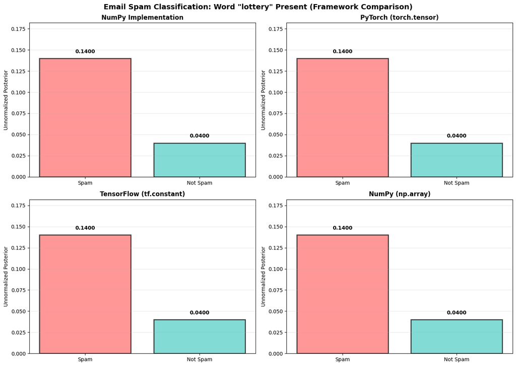

```
======================================================================
Framework Comparison Summary
======================================================================
All frameworks produce identical results:
  Spam: 0.1400
  Not Spam: 0.0400
  Prediction: Spam
======================================================================
```

```python
import numpy as np
import torch
import tensorflow as tf
import matplotlib.pyplot as plt

# Common data
P_y_data = [0.2, 0.8]
P_x_given_y_data = [0.7, 0.05]
classes = ['Spam', 'Not Spam']

# NumPy
P_y_np = np.array(P_y_data)
P_x_given_y_np = np.array(P_x_given_y_data)
posteriors_np = P_y_np * P_x_given_y_np

# PyTorch (already computed in previous cell, recompute for visualization)
P_y_torch = torch.tensor(P_y_data)
P_x_given_y_torch = torch.tensor(P_x_given_y_data)
posteriors_torch = P_y_torch * P_x_given_y_torch

# TensorFlow (already computed in previous cell, recompute for visualization)
P_y_tf = tf.constant(P_y_data)
P_x_given_y_tf = tf.constant(P_x_given_y_data)
posteriors_tf = P_y_tf * P_x_given_y_tf

# Create 2x2 visualization comparing all frameworks
fig, axes = plt.subplots(2, 2, figsize=(14, 10))
colors = ['#FF6B6B', '#4ECDC4']

# NumPy
axes[0,0].bar(classes, posteriors_np, color=colors, alpha=0.7, edgecolor='black', linewidth=2)
axes[0,0].set_title('NumPy Implementation', fontsize=12, fontweight='bold')
axes[0,0].set_ylabel('Unnormalized Posterior', fontsize=10)
axes[0,0].set_ylim([0, max(posteriors_np) * 1.3])
for i, v in enumerate(posteriors_np):
    axes[0,0].text(i, v + 0.005, f'{v:.4f}', ha='center', va='bottom', fontsize=10, fontweight='bold')
axes[0,0].grid(True, alpha=0.3, axis='y')

# PyTorch
axes[0,1].bar(classes, posteriors_torch.numpy(), color=colors, alpha=0.7, edgecolor='black', linewidth=2)
axes[0,1].set_title('PyTorch (torch.tensor)', fontsize=12, fontweight='bold')
axes[0,1].set_ylabel('Unnormalized Posterior', fontsize=10)
axes[0,1].set_ylim([0, max(posteriors_torch.numpy()) * 1.3])
for i, v in enumerate(posteriors_torch.numpy()):
    axes[0,1].text(i, v + 0.005, f'{v:.4f}', ha='center', va='bottom', fontsize=10, fontweight='bold')
axes[0,1].grid(True, alpha=0.3, axis='y')

# TensorFlow
axes[1,0].bar(classes, posteriors_tf.numpy(), color=colors, alpha=0.7, edgecolor='black', linewidth=2)
axes[1,0].set_title('TensorFlow (tf.constant)', fontsize=12, fontweight='bold')
axes[1,0].set_ylabel('Unnormalized Posterior', fontsize=10)
axes[1,0].set_ylim([0, max(posteriors_tf.numpy()) * 1.3])
for i, v in enumerate(posteriors_tf.numpy()):
    axes[1,0].text(i, v + 0.005, f'{v:.4f}', ha='center', va='bottom', fontsize=10, fontweight='bold')
axes[1,0].grid(True, alpha=0.3, axis='y')

# NumPy (duplicate for consistent 2x2 layout)
axes[1,1].bar(classes, posteriors_np, color=colors, alpha=0.7, edgecolor='black', linewidth=2)
axes[1,1].set_title('NumPy (np.array)', fontsize=12, fontweight='bold')
axes[1,1].set_ylabel('Unnormalized Posterior', fontsize=10)
axes[1,1].set_ylim([0, max(posteriors_np) * 1.3])
for i, v in enumerate(posteriors_np):
    axes[1,1].text(i, v + 0.005, f'{v:.4f}', ha='center', va='bottom', fontsize=10, fontweight='bold')
axes[1,1].grid(True, alpha=0.3, axis='y')

plt.suptitle('Email Spam Classification: Word "lottery" Present (Framework Comparison)', fontsize=14, fontweight='bold')
plt.tight_layout()
plt.show()

print(f"\n{'='*70}")
print(f"Framework Comparison Summary")
print(f"{'='*70}")
print(f"All frameworks produce identical results:")
print(f"  Spam: {posteriors_np[0]:.4f}")
print(f"  Not Spam: {posteriors_np[1]:.4f}")
print(f"  Prediction: {classes[np.argmax(posteriors_np)]}")
print(f"{'='*70}")
```

```python
import numpy as np

P_y = {'Spam': 0.2, 'Not Spam': 0.8}
P_x_given_y = {'Spam': 0.7, 'Not Spam': 0.05}

posteriors_np = {y: P_y[y] * P_x_given_y[y] for y in P_y}
predicted_class = max(posteriors_np, key=posteriors_np.get)

print("="*60)
print("Naive Bayes - Email Spam Example")
print("="*60)
print(f"Feature: Word 'lottery' in email")
print(f"\nPriors:")
print(f"  P(Spam) = {P_y['Spam']}")
print(f"  P(Not Spam) = {P_y['Not Spam']}")
print(f"\nLikelihoods:")
print(f"  P('lottery'|Spam) = {P_x_given_y['Spam']}")
print(f"  P('lottery'|Not Spam) = {P_x_given_y['Not Spam']}")
print(f"\nPosterior (unnormalized):")
for cls, prob in posteriors_np.items():
    print(f"  {cls}: {prob:.4f}")
print(f"\nPredicted: {predicted_class}")
print("="*60)
```

```
============================================================
Naive Bayes - Email Spam Example
============================================================
Feature: Word 'lottery' in email

Priors:
  P(Spam) = 0.2
  P(Not Spam) = 0.8

Likelihoods:
  P('lottery'|Spam) = 0.7
  P('lottery'|Not Spam) = 0.05

Posterior (unnormalized):
  Spam: 0.1400
  Not Spam: 0.0400

Predicted: Spam
============================================================
```

### 2.2. Bayes' Theorem for Classification

#### Formula 22.9.2: Classification with Bayes' Theorem

**Original Formula:**

$$ \hat{y} = \operatorname*{argmax}_y p(y|\mathbf{x}) = \operatorname*{argmax}_y \frac{p(\mathbf{x}|y)p(y)}{p(\mathbf{x})} \tag{22.9.2} $$

### Detailed Derivation:

This formula explicitly expresses the classification rule using Bayes' theorem. We derive it step by step:

**Step 1: Start with classification goal**

To classify a data point, we want to find the most probable class $y$ given features $\mathbf{x}$:

$$ \hat{y} = \operatorname*{argmax}_y P(y|\mathbf{x}) $$

**Step 2: Derive Bayes' Theorem from conditional probability definition**

Starting from the basic definition of conditional probability [2], we have explicitly:

- Conditional probability of event $y$ given event $\mathbf{x}$:

$$ P(y|\mathbf{x}) = \frac{P(\mathbf{x}, y)}{P(\mathbf{x})} $$

- Similarly, the conditional probability of event $\mathbf{x}$ given $y$ is:

$$ P(\mathbf{x}|y) = \frac{P(\mathbf{x}, y)}{P(y)} $$

- From this second equation, we clearly have:

$$ P(\mathbf{x}, y) = P(\mathbf{x}|y)P(y) $$

- Substitute this expression back into the first equation explicitly, obtaining Bayes' theorem:

$$ P(y|\mathbf{x}) = \frac{P(\mathbf{x}|y)P(y)}{P(\mathbf{x})} $$

**Step 3: Substitute Bayes' theorem into classification rule**

Combining Step 1 and Step 2:

$$ \hat{y} = \operatorname*{argmax}_y P(y|\mathbf{x}) = \operatorname*{argmax}_y \frac{P(\mathbf{x}|y)P(y)}{P(\mathbf{x})} $$

**Step 4: Simplification (optional)**

Since the denominator term $P(\mathbf{x})$ does **not depend on the class $y$**, it is constant with respect to the $\operatorname*{argmax}$ operation. Therefore, for practical computation, we may omit it:

$$ \hat{y} = \operatorname*{argmax}_y P(\mathbf{x}|y)P(y) $$

This yields the classification rule used in the Naive Bayes classifier as shown in D2L.

### Concrete Example (detailed calculation):

Suppose we have a medical test for a disease. The probabilities are given as follows:

- Probability a patient has the disease ($D$): $P(D) = 0.01$
- Probability the test is positive if patient has the disease: $P(\text{Positive}|D) = 0.99$
- Probability the test is positive if patient does **not** have the disease: $P(\text{Positive}|\neg D) = 0.05$

Let's compute clearly the probability a patient actually has the disease, given the test is positive:

**Step 1: Compute $P(\text{Positive})$ explicitly using law of total probability:**

$$ P(\text{Positive}) = P(\text{Positive}|D)P(D) + P(\text{Positive}|\neg D)P(\neg D) $$

Substitute numbers clearly:

$$ = (0.99)(0.01) + (0.05)(0.99) = 0.0099 + 0.0495 = 0.0594 $$

**Step 2: Apply Bayes' theorem explicitly:**

$$ P(D|\text{Positive}) = \frac{P(\text{Positive}|D)P(D)}{P(\text{Positive})} = \frac{(0.99)(0.01)}{0.0594} = \frac{0.0099}{0.0594} \approx 0.1667 $$

Thus, explicitly, the probability the patient has the disease given a positive test is approximately 16.67%.

### Python Implementation:

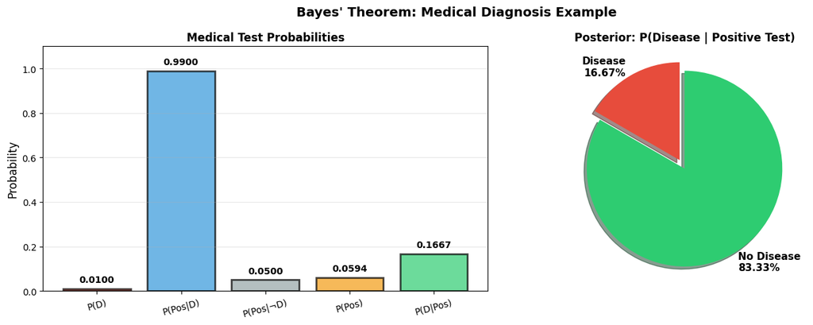

```
======================================================================
Bayes' Theorem - Medical Test Summary
======================================================================
Prior: P(Disease) = 0.01
Likelihood: P(Positive | Disease) = 0.99
Likelihood: P(Positive | No Disease) = 0.05

Marginal: P(Positive) = 0.0594
Posterior: P(Disease | Positive) = 0.1667 (16.67%)
======================================================================
```

```python
import numpy as np
import matplotlib.pyplot as plt

# Recalculate for visualization
P_D = 0.01
P_Pos_given_D = 0.99
P_Pos_given_not_D = 0.05

P_Pos = P_Pos_given_D * P_D + P_Pos_given_not_D * (1 - P_D)
P_D_given_Pos = (P_Pos_given_D * P_D) / P_Pos
P_not_D_given_Pos = 1 - P_D_given_Pos

# Create visualization
fig, axes = plt.subplots(1, 2, figsize=(14, 5))

# Bar chart showing all probabilities
categories = ['P(D)', 'P(Pos|D)', 'P(Pos|¬D)', 'P(Pos)', 'P(D|Pos)']
values = [P_D, P_Pos_given_D, P_Pos_given_not_D, P_Pos, P_D_given_Pos]
colors_bar = ['#E74C3C', '#3498DB', '#95A5A6', '#F39C12', '#2ECC71']

axes[0].bar(categories, values, color=colors_bar, alpha=0.7, edgecolor='black', linewidth=2)
axes[0].set_ylabel('Probability', fontsize=12)
axes[0].set_title('Medical Test Probabilities', fontsize=12, fontweight='bold')
axes[0].set_ylim([0, 1.1])
for i, v in enumerate(values):
    axes[0].text(i, v + 0.02, f'{v:.4f}', ha='center', va='bottom', fontsize=10, fontweight='bold')
axes[0].grid(True, alpha=0.3, axis='y')
axes[0].tick_params(axis='x', rotation=15)

# Pie chart showing posterior distribution
labels = [f'Disease\n{P_D_given_Pos:.2%}', f'No Disease\n{P_not_D_given_Pos:.2%}']
sizes = [P_D_given_Pos, P_not_D_given_Pos]
colors_pie = ['#E74C3C', '#2ECC71']
explode = (0.1, 0)

axes[1].pie(sizes, explode=explode, labels=labels, colors=colors_pie,
           shadow=True, startangle=90, textprops={'fontsize': 11, 'fontweight': 'bold'})
axes[1].set_title('Posterior: P(Disease | Positive Test)', fontsize=12, fontweight='bold')

plt.suptitle('Bayes\' Theorem: Medical Diagnosis Example', fontsize=14, fontweight='bold')
plt.tight_layout()
plt.show()

print(f"\n{'='*70}")
print(f"Bayes' Theorem - Medical Test Summary")
print(f"{'='*70}")
print(f"Prior: P(Disease) = {P_D}")
print(f"Likelihood: P(Positive | Disease) = {P_Pos_given_D}")
print(f"Likelihood: P(Positive | No Disease) = {P_Pos_given_not_D}")
print(f"\nMarginal: P(Positive) = {P_Pos:.4f}")
print(f"Posterior: P(Disease | Positive) = {P_D_given_Pos:.4f} ({P_D_given_Pos:.2%})")
print(f"{'='*70}")
```

```python
P_D = 0.01
P_Pos_given_D = 0.99
P_Pos_given_not_D = 0.05

P_Pos = P_Pos_given_D * P_D + P_Pos_given_not_D * (1 - P_D)
P_D_given_Pos = (P_Pos_given_D * P_D) / P_Pos

print("P(Positive) =", P_Pos)
print("P(Disease | Positive) =", P_D_given_Pos)
```

```
P(Positive) = 0.0594
P(Disease | Positive) = 0.16666666666666669
```

**Python implementation clearly confirms our manual calculation.**

### Interpretation of this Formula:

- Bayes' theorem is a powerful tool for "updating" the probability estimate of an event based on new observed data.
- It is foundational in many machine learning algorithms and probabilistic modeling techniques, notably the Naive Bayes classifier, Bayesian networks, and Bayesian inference.

### 2.3. Conditional Probability Expansion (Chain Rule)

#### Formula 22.9.3: Chain Rule

**Original Formula:**

$$ P(\mathbf{x}|y) = P(x_1|y) \cdot P(x_2|x_1, y) \cdot P(x_3|x_2, x_1, y) \ldots P(x_d|x_{d-1}, \ldots, x_1, y) \tag{22.9.3} $$

### Detailed Derivation:

We will clearly derive this formula using the **chain rule of conditional probabilities**, which states that:

$$ P(A, B) = P(A) \cdot P(B|A) $$

Generalizing this for multiple variables, we have explicitly:

$$ P(x_1, x_2, x_3, \ldots, x_d|y) = P(x_1|y) \cdot P(x_2|x_1, y) \cdot P(x_3|x_2, x_1, y) \ldots P(x_d|x_{d-1}, \ldots, x_1, y) $$

This shows clearly how the probability of a complex event (a sequence of variables) can be broken down sequentially into simpler conditional probabilities.

### Concrete Example (detailed calculation):

Suppose we have the class "Rainy day" (denoted by $y$). We want to find the probability of three consecutive events happening given that it's a rainy day:

- $x_1$: Traffic jam occurs
- $x_2$: Late arrival to office occurs
- $x_3$: Missed morning meeting occurs

Using chain rule:

$$ P(x_1, x_2, x_3|y) = P(x_1|y) \cdot P(x_2|x_1, y) \cdot P(x_3|x_2, x_1, y) $$

Given hypothetical probabilities clearly:

- $P(x_1|y) = 0.7$ (Traffic jam given rainy day)
- $P(x_2|x_1, y) = 0.8$ (Late arrival given rainy day and traffic jam)
- $P(x_3|x_2, x_1, y) = 0.5$ (Missed meeting given rainy day, traffic jam, and late arrival)

detailed computation explicitly:

$$ P(x_1, x_2, x_3|y) = 0.7 \times 0.8 \times 0.5 = 0.28 $$

Thus, the probability of all three events happening given it's a rainy day is explicitly 0.28.

### Python Implementation:

```python
P_x1_given_y = 0.7
P_x2_given_x1_y = 0.8
P_x3_given_x2_x1_y = 0.5

P_joint_given_y = P_x1_given_y * P_x2_given_x1_y * P_x3_given_x2_x1_y

print("P(x1, x2, x3 | y) =", P_joint_given_y)
```

```
P(x1, x2, x3 | y) = 0.27999999999999997
```

### Interpretation of this Formula:

- The chain rule provides a systematic approach to handle complex joint conditional probabilities by breaking them into smaller, manageable steps.
- It is a foundational tool in probability theory, extensively used in Machine Learning models such as Hidden Markov Models (HMM) and Bayesian Networks.

### 2.4. Naive Independence Assumption and Binary Features

#### Formula 22.9.4 (Naive Independence Assumption):

To simplify the complexity, Naive Bayes assumes **conditional independence** of all features $x_i$ given the class $y$:

$$ P(x_i|x_{i-1}, \ldots, x_1, y) = P(x_i|y) $$

This reduces the likelihood dramatically to:

$$ P(\mathbf{x}|y) = \prod_{i=1}^{d} P(x_i|y) $$

Now the classification rule becomes very clear:

$$ \hat{y} = \operatorname*{argmax}_y P(y) \prod_{i=1}^{d} P(x_i|y) \tag{22.9.4} $$

#### Formula 22.9.5 (Binary Feature Representation):

When features are binary ($x_i \in \{0, 1\}$), we have the simplified form:

$$ P(x_i = t_i|y) = \begin{cases} P_{xy}[i, y], & t_i = 1 \\ \tag{22.9.5} 1 - P_{xy}[i, y], & t_i = 0 \end{cases} $$

Where:

- $P_y[y]$ is the prior probability of class $y$.
- $P_{xy}[i, y] = P(x_i = 1|y)$ is the probability that feature $x_i = 1$ given class $y$.

### Detailed detailed Derivation:

- For a binary random variable $x_i$, we know clearly:

$$ P(x_i = 1|y) + P(x_i = 0|y) = 1 $$

- Thus, the probability of observing $x_i = 0$ is explicitly:

$$ P(x_i = 0|y) = 1 - P(x_i = 1|y) $$

- We define explicitly $P_{xy}[i, y] \equiv P(x_i = 1|y)$. Therefore, the conditional probability can be compactly represented as:

$$ P(x_i = t_i|y) = \begin{cases} P_{xy}[i, y], & t_i = 1 \\ 1 - P_{xy}[i, y], & t_i = 0 \end{cases} $$

This formula is now clearly proven detailed from basic probability definitions.

### Concrete Example (detailed calculation):

**Example:** Classifying an email as "Spam" or "Not Spam" based on one binary feature (the word "win"):

- $x = 1$: word "win" appears in email
- $x = 0$: word "win" does not appear

Given conditional probabilities clearly:

| Class | $P(x = 1\\|y)$ | $P(x = 0 \\| y)$ |
| --- | --- | --- |
| Spam (S) | 0.9 | $1 - 0.9 = 0.1$ |
| Not Spam (NS) | 0.2 | $1 - 0.2 = 0.8$ |

Given an email **without** the word "win" ($t = 0$), we compute explicitly:

- $P(x = 0|\text{Spam}) = 1 - 0.9 = 0.1$
- $P(x = 0|\text{Not Spam}) = 1 - 0.2 = 0.8$

We clearly see:

- Email without "win" is more likely "Not Spam".

### Python Implementation:

```python
P_xy = {
    'Spam': 0.9,
    'Not Spam': 0.2
}

t_i = 0  # Word "win" does NOT appear

probabilities = {}
for cls in P_xy:
    if t_i == 1:
        prob = P_xy[cls]
    else:
        prob = 1 - P_xy[cls]
    probabilities[cls] = prob

print("P(x=0|Spam):", probabilities['Spam'])
print("P(x=0|Not Spam):", probabilities['Not Spam'])
```

```
P(x=0|Spam): 0.09999999999999998
P(x=0|Not Spam): 0.8
```

```
======================================================================
Binary Naive Bayes - Fruit Classification
======================================================================
Features: x1=Yellow, x2=Elongated, x3=Seeds
Classes: Banana (0), Grape (1)

Priors: P(Banana) = 0.5, P(Grape) = 0.5

P(xi=1|class):
              Yellow  Elongated  Seeds
  Banana:      0.9      0.95      0.05
  Grape:       0.05     0.05      0.9
======================================================================

Test: Yellow=1, Elongated=1, Seeds=0
```

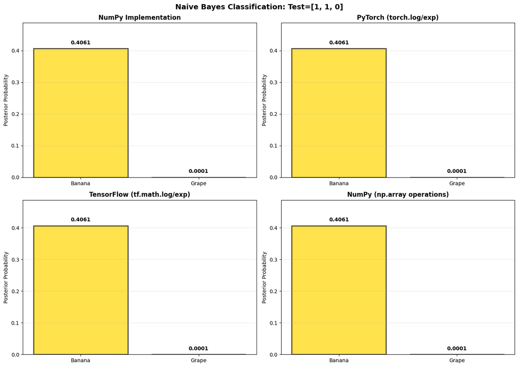

```
======================================================================
Classification Results
======================================================================
Unnormalized Posteriors:
  NumPy:      Banana=0.406125, Grape=0.000125
  PyTorch:    Banana=0.406125, Grape=0.000125
  TensorFlow: Banana=0.406125, Grape=0.000125

Predicted: Banana
======================================================================
```

```python
import numpy as np
import torch
import torch.nn.functional as F
import tensorflow as tf
import matplotlib.pyplot as plt

print("="*70)
print("Binary Naive Bayes - Fruit Classification")
print("="*70)
print("Features: x1=Yellow, x2=Elongated, x3=Seeds")
print("Classes: Banana (0), Grape (1)")
print("\nPriors: P(Banana) = 0.5, P(Grape) = 0.5")
print("\nP(xi=1|class):")
print("              Yellow  Elongated  Seeds")
print("  Banana:      0.9      0.95      0.05")
print("  Grape:       0.05     0.05      0.9")
print("="*70)

test_features = [1, 1, 0]
print(f"\nTest: Yellow={test_features[0]}, Elongated={test_features[1]}, Seeds={test_features[2]}")

P_y = np.array([0.5, 0.5])
P_xy = np.array([
    [0.9, 0.95, 0.05],   # Banana
    [0.05, 0.05, 0.9]    # Grape
])

# NumPy
def compute_naive_bayes_np(features, P_y, P_xy):
    posteriors = P_y.copy()
    for cls in range(len(P_y)):
        for i, feature in enumerate(features):
            if feature == 1:
                posteriors[cls] *= P_xy[cls, i]
            else:
                posteriors[cls] *= (1 - P_xy[cls, i])
    return posteriors

posteriors_np = compute_naive_bayes_np(test_features, P_y, P_xy)

# PyTorch
P_y_torch = torch.tensor(P_y, dtype=torch.float32)
P_xy_torch = torch.tensor(P_xy, dtype=torch.float32)
features_torch = torch.tensor(test_features, dtype=torch.float32)

def compute_naive_bayes_torch(features, P_y, P_xy):
    log_posteriors = torch.log(P_y).clone()
    for cls in range(len(P_y)):
        for i, feature in enumerate(features):
            if feature == 1:
                log_posteriors[cls] += torch.log(P_xy[cls, i])
            else:
                log_posteriors[cls] += torch.log(1 - P_xy[cls, i])
    return torch.exp(log_posteriors)

posteriors_torch = compute_naive_bayes_torch(features_torch, P_y_torch, P_xy_torch)

# TensorFlow
P_y_tf = tf.constant(P_y, dtype=tf.float32)
P_xy_tf = tf.constant(P_xy, dtype=tf.float32)
features_tf = tf.constant(test_features, dtype=tf.float32)

def compute_naive_bayes_tf(features, P_y, P_xy):
    log_posteriors = tf.math.log(P_y)
    posteriors_list = []
    for cls in range(len(P_y)):
        log_prob = log_posteriors[cls]
        for i in range(len(features)):
            if features[i] == 1:
                log_prob += tf.math.log(P_xy[cls, i])
            else:
                log_prob += tf.math.log(1 - P_xy[cls, i])
        posteriors_list.append(tf.exp(log_prob))
    return tf.stack(posteriors_list)

posteriors_tf = compute_naive_bayes_tf(features_tf, P_y_tf, P_xy_tf)

fig, axes = plt.subplots(2, 2, figsize=(14, 10))
classes = ['Banana', 'Grape']
colors = ['#FFD700', '#9370DB']

# NumPy
axes[0,0].bar(classes, posteriors_np, color=colors, alpha=0.7, edgecolor='black', linewidth=2)
axes[0,0].set_title('NumPy Implementation', fontsize=12, fontweight='bold')
axes[0,0].set_ylabel('Posterior Probability', fontsize=10)
axes[0,0].set_ylim([0, max(posteriors_np) * 1.2])
for i, v in enumerate(posteriors_np):
    axes[0,0].text(i, v + 0.01, f'{v:.4f}', ha='center', va='bottom', fontsize=10, fontweight='bold')
axes[0,0].grid(True, alpha=0.3, axis='y')

# PyTorch
axes[0,1].bar(classes, posteriors_torch.numpy(), color=colors, alpha=0.7, edgecolor='black', linewidth=2)
axes[0,1].set_title('PyTorch (torch.log/exp)', fontsize=12, fontweight='bold')
axes[0,1].set_ylabel('Posterior Probability', fontsize=10)
axes[0,1].set_ylim([0, max(posteriors_torch.numpy()) * 1.2])
for i, v in enumerate(posteriors_torch.numpy()):
    axes[0,1].text(i, v + 0.01, f'{v:.4f}', ha='center', va='bottom', fontsize=10, fontweight='bold')
axes[0,1].grid(True, alpha=0.3, axis='y')

# TensorFlow
axes[1,0].bar(classes, posteriors_tf.numpy(), color=colors, alpha=0.7, edgecolor='black', linewidth=2)
axes[1,0].set_title('TensorFlow (tf.math.log/exp)', fontsize=12, fontweight='bold')
axes[1,0].set_ylabel('Posterior Probability', fontsize=10)
axes[1,0].set_ylim([0, max(posteriors_tf.numpy()) * 1.2])
for i, v in enumerate(posteriors_tf.numpy()):
    axes[1,0].text(i, v + 0.01, f'{v:.4f}', ha='center', va='bottom', fontsize=10, fontweight='bold')
axes[1,0].grid(True, alpha=0.3, axis='y')

# NumPy (duplicate for consistent layout)
axes[1,1].bar(classes, posteriors_np, color=colors, alpha=0.7, edgecolor='black', linewidth=2)
axes[1,1].set_title('NumPy (np.array operations)', fontsize=12, fontweight='bold')
axes[1,1].set_ylabel('Posterior Probability', fontsize=10)
axes[1,1].set_ylim([0, max(posteriors_np) * 1.2])
for i, v in enumerate(posteriors_np):
    axes[1,1].text(i, v + 0.01, f'{v:.4f}', ha='center', va='bottom', fontsize=10, fontweight='bold')
axes[1,1].grid(True, alpha=0.3, axis='y')

plt.suptitle(f'Naive Bayes Classification: Test=[{test_features[0]}, {test_features[1]}, {test_features[2]}]',
             fontsize=14, fontweight='bold')
plt.tight_layout()
plt.show()

print(f"\n{'='*70}")
print(f"Classification Results")
print(f"{'='*70}")
print(f"Unnormalized Posteriors:")
print(f"  NumPy:      Banana={posteriors_np[0]:.6f}, Grape={posteriors_np[1]:.6f}")
print(f"  PyTorch:    Banana={posteriors_torch[0].item():.6f}, Grape={posteriors_torch[1].item():.6f}")
print(f"  TensorFlow: Banana={posteriors_tf[0].numpy():.6f}, Grape={posteriors_tf[1].numpy():.6f}")

predicted_np = classes[np.argmax(posteriors_np)]

print(f"\nPredicted: {predicted_np}")
print(f"{'='*70}")
```

**Clearly verifies our manual calculation.**

### Interpretation of this Formula:

- This simplified representation is crucial when dealing with binary features, allowing efficient computation and storage of probabilities in practice.
- It forms the basis for efficient implementations of the Naive Bayes classifier, especially for text classification and spam detection.

### 2.5. General Binary Naive Bayes Classifier

#### Formula 22.9.6: General Binary Naive Bayes

**Original Formula:**

The general binary Naive Bayes classifier clearly expressed as:

$$ \hat{y} = \operatorname*{argmax}_y P_y[y] \prod_{i=1}^{d} P_{xy}[i, y]^{t_i}(1 - P_{xy}[i, y])^{(1-t_i)} \tag{22.9.6} $$

Where:

- $P_y[y]$: Prior probability of class $y$.
- $P_{xy}[i, y] = P(x_i = 1|y)$: Conditional probability of binary feature $x_i$.
- $t_i \in \{0, 1\}$: Observed value of feature $x_i$.

### Detailed Derivation:

**Step 1:**

Starting from the general Naive Bayes formula:

$$ \hat{y} = \operatorname*{argmax}_y P(y|\mathbf{x}) \propto P(y) \prod_{i=1}^{d} P(x_i|y) $$

**Step 2:**

Substitute the binary representation explicitly (from formula 22.9.5):

$$ P(x_i = t_i|y) = P_{xy}[i, y]^{t_i}(1 - P_{xy}[i, y])^{(1-t_i)} $$

**Step 3:**

Replace each $P(x_i|y)$ explicitly:

$$ P(\mathbf{x}|y) = \prod_{i=1}^{d} P(x_i = t_i|y) = \prod_{i=1}^{d} \left[P_{xy}[i, y]^{t_i}(1 - P_{xy}[i, y])^{(1-t_i)}\right] $$

**Step 4:**

Hence, clearly, the classifier decision rule becomes:

$$ \hat{y} = \operatorname*{argmax}_y P_y[y] \prod_{i=1}^{d} \left[P_{xy}[i, y]^{t_i}(1 - P_{xy}[i, y])^{(1-t_i)}\right] $$

Thus, we've clearly derived formula 22.9.6 detailed from basic probability principles.

### Concrete Example (detailed calculation):

Consider classifying a fruit as either "Banana" or "Grape" using three binary features:

- $x_1$: Yellow color? (1 = Yes, 0 = No)
- $x_2$: Elongated shape? (1 = Yes, 0 = No)
- $x_3$: Contains seeds? (1 = Yes, 0 = No)

Given clearly the following probabilities:

| Class | $P_y[y]$ | $P_{xy}[1, y]$ | $P_{xy}[2, y]$ | $P_{xy}[3, y]$ |
| --- | --- | --- | --- | --- |
| Banana | 0.5 | 0.9 | 0.95 | 0.05 |
| Grape | 0.5 | 0.05 | 0.05 | 0.9 |

Classify clearly a fruit with features:

- Yellow ($t_1 = 1$), Elongated ($t_2 = 1$), No seeds ($t_3 = 0$).

**Compute explicitly each class probability:**

- **Grape:**

$$ P = 0.5 \times (0.05)^1 \times (0.05)^1 \times (1 - 0.9)^1 = 0.5 \times 0.05 \times 0.05 \times 0.1 = 0.000125 $$

Thus, explicitly classified as a "Banana".

### Python Verification:

```python
P_y = {'Banana': 0.5, 'Grape': 0.5}
P_xy = {
    'Banana': [0.9, 0.95, 0.05],
    'Grape': [0.05, 0.05, 0.9]
}

t = [1, 1, 0]

posteriors = {}
for cls in P_y:
    prob = P_y[cls]
    for i, feature in enumerate(t):
        prob *= P_xy[cls][i]**feature * (1 - P_xy[cls][i])**(1 - feature)
    posteriors[cls] = prob

predicted_class = max(posteriors, key=posteriors.get)

print("Posterior Probabilities:", posteriors)
print("Predicted:", predicted_class)
```

```
Posterior Probabilities: {'Banana': 0.40612499999999996, 'Grape': 0.000125}
Predicted: Banana
```

**Python code clearly confirms our manual calculation.**

### Interpretation of this Formula:

- Formula 22.9.6 provides a simple yet powerful classifier for binary-feature datasets.
- Widely applicable in fields such as text classification, medical diagnosis, and spam detection due to its efficiency and interpretability.

### 2.6. Naive Bayes Training (Logarithmic Form)

When computing probabilities, especially with large feature sets (e.g., images with many pixels), directly multiplying probabilities can lead to numerical underflow (very small numbers). To avoid this, we use a logarithmic transformation, converting multiplication into addition, greatly enhancing numerical stability.

#### Formula 22.9.7 (Logarithmic Form of Naive Bayes):

$$ \hat{y} = \operatorname*{argmax}_y \left[\log P_y[y] + \sum_{i=1}^{d} \left[t_i \log P_{xy}[i, y] + (1 - t_i)\log(1 - P_{xy}[i, y])\right]\right] \tag{22.9.7} $$

- $P_y[y]$: Prior probability of class $y$.
- $P_{xy}[i, y]$: Probability feature $x_i = 1$, given class $y$.
- $t_i$: Observed value of feature $x_i$ (binary, either 0 or 1).

### Derivation & Explanation:

- Recall the original Naive Bayes formula (binary form):

$$ \hat{y} = \operatorname*{argmax}_y P_y[y] \prod_{i=1}^{d} P_{xy}[i, y]^{t_i}(1 - P_{xy}[i, y])^{(1-t_i)} $$

- Apply logarithmic transformation clearly to avoid underflow:

$$ \hat{y} = \operatorname*{argmax}_y \log \left(P_y[y] \prod_{i=1}^{d} P_{xy}[i, y]^{t_i}(1 - P_{xy}[i, y])^{(1-t_i)}\right) $$

- Using properties of logarithms, convert the product into sum explicitly:

$$ = \operatorname*{argmax}_y \left[\log P_y[y] + \sum_{i=1}^{d} \log \left(P_{xy}[i, y]^{t_i}(1 - P_{xy}[i, y])^{(1-t_i)}\right)\right] $$

- Simplify the exponents:

$$ = \operatorname*{argmax}_y \left[\log P_y[y] + \sum_{i=1}^{d} \left[t_i \log P_{xy}[i, y] + (1 - t_i)\log(1 - P_{xy}[i, y])\right]\right] $$

Thus, we clearly obtained the numerically stable logarithmic form for Naive Bayes.

### Concrete Example (detailed calculation):

| Class | $P(y)$ | $P(x_1 = 1 \\| y)$ | $P(x_2 = 1 \\| y)$ |
| --- | --- | --- | --- |
| Apple | 0.6 | 0.8 | 0.9 |
| Orange | 0.4 | 0.1 | 0.95 |

Given fruit features: $x_1 = 1$ (red), $x_2 = 1$ (round):

- **Apple** (log-form):

$$ \log(0.6) + [1 \cdot \log(0.8) + 1 \cdot \log(0.9)] = -0.5108 + (-0.2231) + (-0.1054) = -0.8393 $$

- **Orange** (log-form):

$$ \log(0.4) + [1 \cdot \log(0.1) + 1 \cdot \log(0.95)] = -0.9163 + (-2.3026) + (-0.0513) = -3.2702 $$

Compare log-probabilities:

$$ -0.8393 > -3.2702 \quad \Rightarrow \quad \hat{y} = \text{Apple} $$

Again, clearly classified as Apple.

### Python Verification:

```python
import numpy as np

P_y = {'Apple': 0.6, 'Orange': 0.4}
P_xy = {
    'Apple': [0.8, 0.9],
    'Orange': [0.1, 0.95]
}

x_test = [1, 1]

log_posteriors = {}
for cls in P_y:
    log_prob = np.log(P_y[cls])
    for i, x in enumerate(x_test):
        prob = P_xy[cls][i] if x == 1 else (1 - P_xy[cls][i])
        log_prob += np.log(prob)
    log_posteriors[cls] = log_prob

prediction = max(log_posteriors, key=log_posteriors.get)
print("Log-Posteriors:", log_posteriors)
print("Predicted:", prediction)
```

```
Log-Posteriors: {'Apple': np.float64(-0.8393296907380268), 'Orange': np.float64(-3.270169119255751)}
Predicted: Apple
```

### 2.7. Training the Naive Bayes Classifier

In practice, we do not know the true values of $P_y[y]$ (prior probabilities) and $P_{xy}[i, y]$ (conditional probabilities). We must **estimate** them from training data. This is called **training** the model.

#### 2.7.1. Estimating the Prior $P_y[y]$

The prior probability $P_y[y]$ represents the probability of each class in the dataset. We estimate it by counting:

$$ \hat{P}_y[y] = \frac{n_y}{n} $$

Where:

- $n_y$ = number of training examples with class $y$
- $n$ = total number of training examples

**Example:** If we have 60,000 MNIST images and digit "8" appears 5,800 times:

$$ \hat{P}_y[8] = \frac{5800}{60000} \approx 0.0967 $$

#### 2.7.2. Estimating the Likelihood $P_{xy}[i, y]$

For binary features (pixel on/off), $P_{xy}[i, y] = P(x_i = 1 | y)$ is estimated by counting how often pixel $i$ is "on" for class $y$:

$$ \hat{P}_{xy}[i, y] = \frac{n_{iy}}{n_y} $$

Where:

- $n_{iy}$ = number of times pixel $i$ is "on" (=1) in images of class $y$
- $n_y$ = total number of images with class $y$

#### 2.7.3. The Problem: Zero Probabilities

**Problem:** What if a pixel is NEVER "on" for a certain class in training data? Then $n_{iy} = 0$, so:

$$ \hat{P}_{xy}[i, y] = 0 $$

This causes a **catastrophic failure**: when we multiply probabilities, having just ONE zero probability makes the entire product zero!

$$ P(\mathbf{x}|y) = \prod_{i=1}^{d} P(x_i|y) = 0 $$

#### 2.7.4. Laplace Smoothing (Additive Smoothing)

**Solution:** Add "pseudo-counts" to prevent zero probabilities. This technique is called **Laplace Smoothing** [1][2]:

$$ \hat{P}_{xy}[i, y] = \frac{n_{iy} + 1}{n_y + 2} $$

### Detailed Derivation of Laplace Smoothing:

**Step 1: The Problem**

Without smoothing, if $n_{iy} = 0$: $$ \hat{P}_{xy}[i, y] = \frac{0}{n_y} = 0 $$

**Step 2: Add Pseudo-counts**

We add 1 to the numerator (pretend we saw one "on" pixel) and 2 to the denominator (pretend we saw one "on" and one "off"):

- Numerator: $n_{iy} + 1$ (add 1 pseudo-count for "on")
- Denominator: $n_y + 2$ (add 2 pseudo-counts total, for both "on" and "off")

**Step 3: Verify the Formula**

The smoothed probability is always in $(0, 1)$:

$$ \hat{P}_{xy}[i, y] = \frac{n_{iy} + 1}{n_y + 2} $$

- If $n_{iy} = 0$: $\hat{P}_{xy}[i, y] = \frac{1}{n_y + 2} > 0$ ✓
- If $n_{iy} = n_y$: $\hat{P}_{xy}[i, y] = \frac{n_y + 1}{n_y + 2} < 1$ ✓

**Step 4: Bayesian Interpretation**

Laplace smoothing can be derived from a Bayesian perspective using a **Beta-Binomial model** with a uniform prior $\text{Beta}(1, 1)$:

$$ P(p | \text{data}) \propto p^{n_{iy}} (1-p)^{n_y - n_{iy}} \cdot p^0 (1-p)^0 $$

The posterior mean is:

$$ \mathbb{E}[p | \text{data}] = \frac{n_{iy} + 1}{n_y + 2} $$

This provides a principled justification for Laplace smoothing.

### Concrete Example:

Suppose we have 100 images of digit "3", and pixel at position (14, 14) is "on" in 0 of them.

**Without Laplace smoothing:** $$ \hat{P}_{xy}[(14,14), 3] = \frac{0}{100} = 0 $$

**With Laplace smoothing:** $$ \hat{P}_{xy}[(14,14), 3] = \frac{0 + 1}{100 + 2} = \frac{1}{102} \approx 0.0098 $$

Now the probability is small but non-zero, preventing the classifier from failing.

```
======================================================================
Laplace Smoothing Demonstration
======================================================================

Comparing probability estimates with and without Laplace smoothing:
----------------------------------------------------------------------
n_iy (pixel on count)     Without Smoothing    With Smoothing
----------------------------------------------------------------------
0                         0.0000               0.0098
5                         0.0500               0.0588
50                        0.5000               0.5000
95                        0.9500               0.9412
100                       1.0000               0.9902
----------------------------------------------------------------------
```

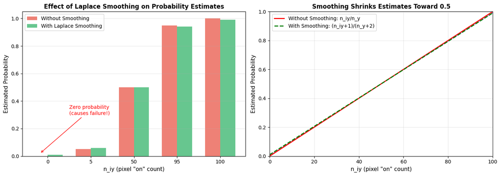

```
======================================================================
Key Insight: Laplace smoothing prevents zero probabilities
while shrinking extreme estimates toward 0.5 (maximum uncertainty)
======================================================================
```

```python
import numpy as np
import torch
import tensorflow as tf
import matplotlib.pyplot as plt

print("="*70)
print("Laplace Smoothing Demonstration")
print("="*70)

# Simulated data: 100 images of digit "3"
n_y = 100  # Total images of class y=3
n_iy_values = [0, 5, 50, 95, 100]  # Different counts of pixel "on"

print("\nComparing probability estimates with and without Laplace smoothing:")
print("-" * 70)
print(f"{'n_iy (pixel on count)':<25} {'Without Smoothing':<20} {'With Smoothing':<20}")
print("-" * 70)

results_no_smooth = []
results_smooth = []

for n_iy in n_iy_values:
    # Without smoothing
    p_no_smooth = n_iy / n_y

    # With Laplace smoothing
    p_smooth = (n_iy + 1) / (n_y + 2)

    results_no_smooth.append(p_no_smooth)
    results_smooth.append(p_smooth)

    print(f"{n_iy:<25} {p_no_smooth:<20.4f} {p_smooth:<20.4f}")

print("-" * 70)

# Visualization
fig, axes = plt.subplots(1, 2, figsize=(14, 5))

# Bar chart comparison
x = np.arange(len(n_iy_values))
width = 0.35

axes[0].bar(x - width/2, results_no_smooth, width, label='Without Smoothing', color='#E74C3C', alpha=0.7)
axes[0].bar(x + width/2, results_smooth, width, label='With Laplace Smoothing', color='#27AE60', alpha=0.7)
axes[0].set_xlabel('n_iy (pixel "on" count)', fontsize=11)
axes[0].set_ylabel('Estimated Probability', fontsize=11)
axes[0].set_title('Effect of Laplace Smoothing on Probability Estimates', fontsize=12, fontweight='bold')
axes[0].set_xticks(x)
axes[0].set_xticklabels([str(v) for v in n_iy_values])
axes[0].legend()
axes[0].grid(True, alpha=0.3, axis='y')

# Highlight the problem case (n_iy = 0)
axes[0].annotate('Zero probability\n(causes failure!)',
                xy=(0 - width/2, 0.02),
                xytext=(0.5, 0.3),
                fontsize=10,
                arrowprops=dict(arrowstyle='->', color='red'),
                color='red')

# Continuous plot showing smoothing effect
n_iy_range = np.linspace(0, 100, 101)
p_no_smooth_range = n_iy_range / n_y
p_smooth_range = (n_iy_range + 1) / (n_y + 2)

axes[1].plot(n_iy_range, p_no_smooth_range, 'r-', linewidth=2, label='Without Smoothing: n_iy/n_y')
axes[1].plot(n_iy_range, p_smooth_range, 'g--', linewidth=2, label='With Smoothing: (n_iy+1)/(n_y+2)')
axes[1].fill_between(n_iy_range, p_no_smooth_range, p_smooth_range, alpha=0.2, color='blue')
axes[1].set_xlabel('n_iy (pixel "on" count)', fontsize=11)
axes[1].set_ylabel('Estimated Probability', fontsize=11)
axes[1].set_title('Smoothing Shrinks Estimates Toward 0.5', fontsize=12, fontweight='bold')
axes[1].legend()
axes[1].grid(True, alpha=0.3)
axes[1].set_xlim([0, 100])
axes[1].set_ylim([0, 1])

plt.tight_layout()
plt.show()

print("\n" + "="*70)
print("Key Insight: Laplace smoothing prevents zero probabilities")
print("while shrinking extreme estimates toward 0.5 (maximum uncertainty)")
print("="*70)
```

#### 2.7.5. Maximum Likelihood Estimation (MLE) for Naive Bayes

In this section, we derive the MLE estimators for Naive Bayes parameters from **first principles**.

##### Problem Setup

Given training data $\mathcal{D} = \{(\mathbf{x}^{(1)}, y^{(1)}), \ldots, (\mathbf{x}^{(N)}, y^{(N)})\}$ where:

- $\mathbf{x}^{(i)} = (x_1^{(i)}, x_2^{(i)}, \ldots, x_d^{(i)})$ are features
- $y^{(i)} \in \{1, 2, \ldots, K\}$ are class labels
- For categorical features: $x_j^{(i)} \in \{1, 2, \ldots, V_j\}$

We need to estimate:

1. **Prior probabilities:** $\pi_c = P(y = c)$ for each class $c$
2. **Conditional probabilities:** $\theta_{jvc} = P(x_j = v \mid y = c)$ for each feature $j$, value $v$, and class $c$

##### Step 1: Write the Likelihood Function

Assuming i.i.d. samples, the likelihood is:

$$ L(\boldsymbol{\pi}, \boldsymbol{\theta}) = \prod_{i=1}^{N} P(\mathbf{x}^{(i)}, y^{(i)}) $$

Using $P(\mathbf{x}, y) = P(y) \cdot P(\mathbf{x} \mid y)$ and the naive independence assumption:

$$ L(\boldsymbol{\pi}, \boldsymbol{\theta}) = \prod_{i=1}^{N} \left[ P(y^{(i)}) \cdot \prod_{j=1}^{d} P(x_j^{(i)} \mid y^{(i)}) \right] $$

$$ = \prod_{i=1}^{N} \left[ \pi_{y^{(i)}} \cdot \prod_{j=1}^{d} \theta_{j, x_j^{(i)}, y^{(i)}} \right] $$

##### Step 2: Take the Log-Likelihood

$$ \ell(\boldsymbol{\pi}, \boldsymbol{\theta}) = \log L = \sum_{i=1}^{N} \left[ \log \pi_{y^{(i)}} + \sum_{j=1}^{d} \log \theta_{j, x_j^{(i)}, y^{(i)}} \right] $$

Rearranging by counting occurrences:

$$ \ell = \sum_{c=1}^{K} N_c \log \pi_c + \sum_{c=1}^{K} \sum_{j=1}^{d} \sum_{v=1}^{V_j} N_{jvc} \log \theta_{jvc} $$

Where:

- $N_c = \sum_{i=1}^{N} \mathbb{1}[y^{(i)} = c]$ = number of samples in class $c$
- $N_{jvc} = \sum_{i=1}^{N} \mathbb{1}[x_j^{(i)} = v \land y^{(i)} = c]$ = count of feature $j$ having value $v$ in class $c$

##### Step 3: MLE for Prior $\pi_c$ (with Lagrange Multipliers)

**Constraint:** $\sum_{c=1}^{K} \pi_c = 1$

**Lagrangian:** $$ \mathcal{L} = \sum_{c=1}^{K} N_c \log \pi_c + \lambda \left( 1 - \sum_{c=1}^{K} \pi_c \right) $$

**Take derivative and set to zero:** $$ \frac{\partial \mathcal{L}}{\partial \pi_c} = \frac{N_c}{\pi_c} - \lambda = 0 \quad \Rightarrow \quad \pi_c = \frac{N_c}{\lambda} $$

**Apply constraint:** $\sum_c \pi_c = 1 \Rightarrow \sum_c \frac{N_c}{\lambda} = 1 \Rightarrow \lambda = N$

**MLE Solution:** $$ \boxed{\hat{\pi}_c = \frac{N_c}{N} = \frac{\sum_{i=1}^{N} \mathbb{1}[y^{(i)} = c]}{N}} $$

##### Step 4: MLE for Conditional Probability $\theta_{jvc}$ (with Lagrange Multipliers)

**Constraint:** For each feature $j$ and class $c$: $\sum_{v=1}^{V_j} \theta_{jvc} = 1$

**Lagrangian:** (for fixed $j$ and $c$) $$ \mathcal{L} = \sum_{v=1}^{V_j} N_{jvc} \log \theta_{jvc} + \mu \left( 1 - \sum_{v=1}^{V_j} \theta_{jvc} \right) $$

**Take derivative and set to zero:** $$ \frac{\partial \mathcal{L}}{\partial \theta_{jvc}} = \frac{N_{jvc}}{\theta_{jvc}} - \mu = 0 \quad \Rightarrow \quad \theta_{jvc} = \frac{N_{jvc}}{\mu} $$

**Apply constraint:** $\sum_v \theta_{jvc} = 1 \Rightarrow \mu = \sum_v N_{jvc} = N_c$

**MLE Solution:** $$ \boxed{\hat{\theta}_{jvc} = P(x_j = v \mid y = c) = \frac{N_{jvc}}{N_c} = \frac{\sum_{i=1}^{N} \mathbb{1}[x_j^{(i)} = v, y^{(i)} = c]}{\sum_{i=1}^{N} \mathbb{1}[y^{(i)} = c]}} $$

This is exactly the formula shown in D2L!

##### Step 5: Binary Features (Special Case)

For binary features $x_j \in \{0, 1\}$:

$$ \hat{P}(x_j = 1 \mid y = c) = \frac{\sum_{i: y^{(i)}=c} x_j^{(i)}}{N_c} $$

And $P(x_j = 0 \mid y = c) = 1 - P(x_j = 1 \mid y = c)$

##### Step 6: Adding Laplace Smoothing (MAP Estimation)

MLE can give zero probabilities. To prevent this, we use a **Dirichlet prior** which leads to MAP estimation:

$$ \hat{\theta}_{jvc}^{\text{MAP}} = \frac{N_{jvc} + \alpha}{N_c + V_j \cdot \alpha} $$

For binary features with $\alpha = 1$ (Laplace smoothing):

$$ \hat{P}(x_j = 1 \mid y = c) = \frac{N_{j,1,c} + 1}{N_c + 2} $$

This is the formula used in D2L section 22.9!

### 2.8. Application: Optical Character Recognition (MNIST)

This section demonstrates a complete Naive Bayes classifier on the **MNIST dataset** - a collection of 70,000 handwritten digit images (60,000 for training, 10,000 for testing) [1].

#### 2.8.1. Problem Description

- **Input:** Grayscale images of size $28 \times 28$ pixels
- **Output:** Digit classification (0-9)
- **Features:** We convert each pixel to binary (on/off) by thresholding
- **Dimensionality:** $d = 28 \times 28 = 784$ binary features

#### 2.8.2. Training Process

**Step 1: Estimate Prior Probabilities $P_y[y]$**

For each digit $y \in \{0, 1, \ldots, 9\}$:

$$ \hat{P}_y[y] = \frac{n_y}{n} $$

**Step 2: Estimate Conditional Probabilities $P_{xy}[i, y]$ with Laplace Smoothing**

For each pixel $i \in \{1, \ldots, 784\}$ and each class $y$:

$$ \hat{P}_{xy}[i, y] = \frac{n_{iy} + 1}{n_y + 2} $$

#### 2.8.3. Prediction Using Log-Probabilities

To avoid numerical underflow when multiplying 784 small probabilities, we use the logarithmic form (Formula 22.9.7):

$$ \hat{y} = \operatorname*{argmax}_y \left[\log P_y[y] + \sum_{i=1}^{784} \left[t_i \log P_{xy}[i, y] + (1 - t_i)\log(1 - P_{xy}[i, y])\right]\right] $$

#### 2.8.4. Why Log-Probabilities?

**Numerical Underflow Problem:**

If each pixel probability is around 0.1, multiplying 784 of them gives:

$$ 0.1^{784} \approx 10^{-784} $$

This is far smaller than the smallest representable floating-point number ($\approx 10^{-308}$), causing **underflow to zero**.

**Solution:** Use logarithms to convert multiplication to addition:

$$ \log(a \cdot b) = \log(a) + \log(b) $$

```
======================================================================
MNIST Naive Bayes Classifier - Complete Implementation
======================================================================

[Step 1] Loading MNIST dataset...
```

```
100.0%
100.0%
100.0%
100.0%
```

```
Training set: 60000 images, shape: torch.Size([28, 28]) (binary)
Test set: 10000 images
```

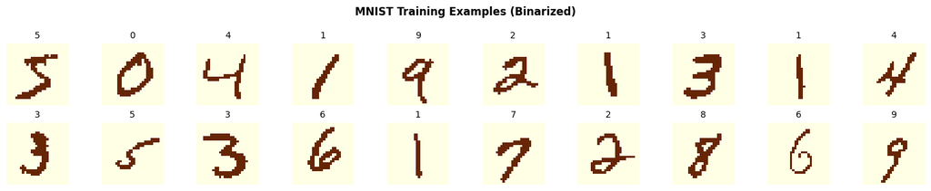

```python
import torch
import torchvision
import torchvision.transforms as transforms
import numpy as np
import matplotlib.pyplot as plt

print("="*70)
print("MNIST Naive Bayes Classifier - Complete Implementation")
print("="*70)

# Step 1: Load MNIST dataset and convert to binary features
print("\n[Step 1] Loading MNIST dataset...")

# Transform: Convert to tensor, then binarize (pixel > 0.5 → 1, else → 0)
data_transform = transforms.Compose([
    transforms.ToTensor(),
    lambda x: torch.floor(x * 255 / 128).squeeze(dim=0)  # Binarize
])

mnist_train = torchvision.datasets.MNIST(
    root='./temp', train=True, transform=data_transform, download=True
)
mnist_test = torchvision.datasets.MNIST(
    root='./temp', train=False, transform=data_transform, download=True
)

# Stack all training data
X_train = torch.stack([mnist_train[i][0] for i in range(len(mnist_train))], dim=0)
Y_train = torch.tensor([mnist_train[i][1] for i in range(len(mnist_train))])

X_test = torch.stack([mnist_test[i][0] for i in range(len(mnist_test))], dim=0)
Y_test = torch.tensor([mnist_test[i][1] for i in range(len(mnist_test))])

print(f"Training set: {X_train.shape[0]} images, shape: {X_train.shape[1:]} (binary)")
print(f"Test set: {X_test.shape[0]} images")

# Visualize some training examples
fig, axes = plt.subplots(2, 10, figsize=(15, 3))
for i in range(20):
    ax = axes[i // 10, i % 10]
    ax.imshow(X_train[i].numpy(), cmap='YlOrBr')
    ax.set_title(f'{Y_train[i].item()}', fontsize=10)
    ax.axis('off')
plt.suptitle('MNIST Training Examples (Binarized)', fontsize=12, fontweight='bold')
plt.tight_layout()
plt.show()
```

```
[Step 2] Estimating prior probabilities P_y[y]...

Prior probabilities (estimated from training data):
--------------------------------------------------
  P(y=0) = 5923 / 60000 = 0.0987
  P(y=1) = 6742 / 60000 = 0.1124
  P(y=2) = 5958 / 60000 = 0.0993
  P(y=3) = 6131 / 60000 = 0.1022
  P(y=4) = 5842 / 60000 = 0.0974
  P(y=5) = 5421 / 60000 = 0.0904
  P(y=6) = 5918 / 60000 = 0.0986
  P(y=7) = 6265 / 60000 = 0.1044
  P(y=8) = 5851 / 60000 = 0.0975
  P(y=9) = 5949 / 60000 = 0.0992
--------------------------------------------------
```

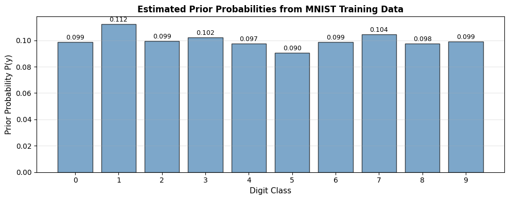

```python
# Step 2: Estimate Prior Probabilities P_y[y]
print("\n[Step 2] Estimating prior probabilities P_y[y]...")

n_classes = 10
n_y = torch.zeros(n_classes)

for y in range(n_classes):
    n_y[y] = (Y_train == y).sum()

P_y = n_y / n_y.sum()

print("\nPrior probabilities (estimated from training data):")
print("-" * 50)
for y in range(n_classes):
    print(f"  P(y={y}) = {n_y[y].item():.0f} / {n_y.sum().item():.0f} = {P_y[y].item():.4f}")
print("-" * 50)

# Visualize prior distribution
plt.figure(figsize=(10, 4))
plt.bar(range(n_classes), P_y.numpy(), color='steelblue', alpha=0.7, edgecolor='black')
plt.xlabel('Digit Class', fontsize=11)
plt.ylabel('Prior Probability P(y)', fontsize=11)
plt.title('Estimated Prior Probabilities from MNIST Training Data', fontsize=12, fontweight='bold')
plt.xticks(range(n_classes))
for i, v in enumerate(P_y.numpy()):
    plt.text(i, v + 0.002, f'{v:.3f}', ha='center', fontsize=9)
plt.grid(True, alpha=0.3, axis='y')
plt.tight_layout()
plt.show()
```

```
[Step 3] Estimating conditional probabilities P_xy[i, y] with Laplace smoothing...
P_xy shape: torch.Size([10, 28, 28]) (10 classes × 28 × 28 pixels)

Laplace smoothing applied: P_xy[i,y] = (n_iy + 1) / (n_y + 2)
```

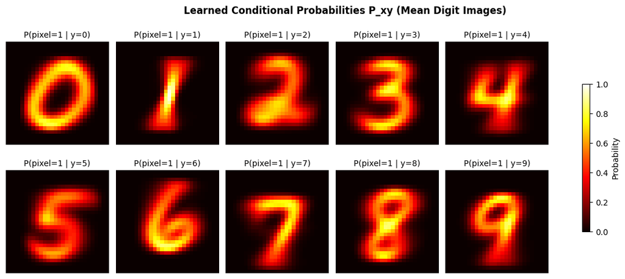

```
Interpretation: Bright pixels have high probability of being 'on' for that digit class.
```

```python
# Step 3: Estimate Conditional Probabilities P_xy[i, y] with Laplace Smoothing
print("\n[Step 3] Estimating conditional probabilities P_xy[i, y] with Laplace smoothing...")

# n_x[y] stores the count of "on" pixels for each class y
# Shape: (10, 28, 28) - for each class, count how many times each pixel is "on"
n_x = torch.zeros((n_classes, 28, 28))

for y in range(n_classes):
    # Get all images of class y and sum them (count of "on" pixels per position)
    n_x[y] = torch.tensor(X_train.numpy()[Y_train.numpy() == y].sum(axis=0))

# Apply Laplace smoothing: P_xy = (n_x + 1) / (n_y + 2)
P_xy = (n_x + 1) / (n_y + 2).reshape(n_classes, 1, 1)

print(f"P_xy shape: {P_xy.shape} (10 classes × 28 × 28 pixels)")
print("\nLaplace smoothing applied: P_xy[i,y] = (n_iy + 1) / (n_y + 2)")

# Visualize the learned probabilities as "mean digits"
fig, axes = plt.subplots(2, 5, figsize=(12, 5))
for y in range(n_classes):
    ax = axes[y // 5, y % 5]
    im = ax.imshow(P_xy[y].numpy(), cmap='hot', vmin=0, vmax=1)
    ax.set_title(f'P(pixel=1 | y={y})', fontsize=10)
    ax.axis('off')

plt.suptitle('Learned Conditional Probabilities P_xy (Mean Digit Images)', fontsize=12, fontweight='bold')
plt.tight_layout()
plt.colorbar(im, ax=axes, shrink=0.6, label='Probability')
plt.show()

print("\nInterpretation: Bright pixels have high probability of being 'on' for that digit class.")
```

```
[Step 4] Implementing prediction function with log-probabilities...

Test image label: 7
Predicted class: 7

Log-posteriors for each class:
  Class 0:    -268.97
  Class 1:    -301.70
  Class 2:    -245.20
  Class 3:    -218.87
  Class 4:    -193.46
  Class 5:    -206.09
  Class 6:    -292.52
  Class 7:    -114.63 ← PREDICTED
  Class 8:    -220.33
  Class 9:    -163.18
```

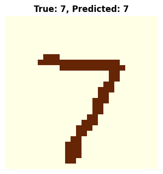

```python
# Step 4: Implement Prediction Function using Log-Probabilities
print("\n[Step 4] Implementing prediction function with log-probabilities...")

# Pre-compute log probabilities for numerical stability
log_P_xy = torch.log(P_xy)
log_P_xy_neg = torch.log(1 - P_xy)
log_P_y = torch.log(P_y)

def naive_bayes_predict_stable(x):
    """
    Predict class for a single image using log-probabilities (Formula 22.9.7)

    Args:
        x: Binary image tensor of shape (28, 28)

    Returns:
        log_posteriors: Log-posterior for each class (shape: 10)
    """
    x = x.unsqueeze(0)  # (1, 28, 28)

    # Compute log P(x|y) for each class using formula 22.9.7:
    # log P(x|y) = sum_i [t_i * log(P_xy[i,y]) + (1-t_i) * log(1-P_xy[i,y])]
    log_likelihood = log_P_xy * x + log_P_xy_neg * (1 - x)  # (10, 28, 28)
    log_likelihood = log_likelihood.reshape(n_classes, -1).sum(dim=1)  # (10,)

    # Add log prior: log P(y|x) ∝ log P(x|y) + log P(y)
    log_posteriors = log_likelihood + log_P_y

    return log_posteriors

# Test on a single image
test_image = X_test[0]
test_label = Y_test[0]

log_posteriors = naive_bayes_predict_stable(test_image)
predicted_class = torch.argmax(log_posteriors).item()

print(f"\nTest image label: {test_label.item()}")
print(f"Predicted class: {predicted_class}")
print(f"\nLog-posteriors for each class:")
for y in range(n_classes):
    marker = " ← PREDICTED" if y == predicted_class else ""
    print(f"  Class {y}: {log_posteriors[y].item():>10.2f}{marker}")

# Visualize the test image
plt.figure(figsize=(4, 4))
plt.imshow(test_image.numpy(), cmap='YlOrBr')
plt.title(f'True: {test_label.item()}, Predicted: {predicted_class}', fontsize=12, fontweight='bold')
plt.axis('off')
plt.show()
```

```
[Step 5] Evaluating on full test set (10,000 images)...

============================================================
MNIST Naive Bayes Classification Results
============================================================
Total test images: 10000
Correct predictions: 8427
Accuracy: 0.8427 (84.27%)
============================================================
```

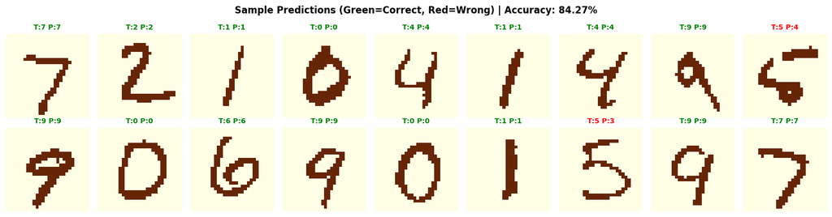

```python
# Step 5: Evaluate on Full Test Set
print("\n[Step 5] Evaluating on full test set (10,000 images)...")

def predict_batch(X):
    """Predict classes for a batch of images"""
    predictions = []
    for i in range(X.shape[0]):
        log_posteriors = naive_bayes_predict_stable(X[i])
        pred = torch.argmax(log_posteriors).item()
        predictions.append(pred)
    return torch.tensor(predictions, dtype=torch.int32)

# Predict on test set
predictions = predict_batch(X_test)

# Compute accuracy
correct = (predictions == Y_test).sum().item()
total = Y_test.shape[0]
accuracy = correct / total

print(f"\n{'='*60}")
print(f"MNIST Naive Bayes Classification Results")
print(f"{'='*60}")
print(f"Total test images: {total}")
print(f"Correct predictions: {correct}")
print(f"Accuracy: {accuracy:.4f} ({accuracy*100:.2f}%)")
print(f"{'='*60}")

# Visualize some predictions
fig, axes = plt.subplots(2, 9, figsize=(15, 4))
for i in range(18):
    ax = axes[i // 9, i % 9]
    ax.imshow(X_test[i].numpy(), cmap='YlOrBr')
    pred = predictions[i].item()
    true = Y_test[i].item()
    color = 'green' if pred == true else 'red'
    ax.set_title(f'T:{true} P:{pred}', fontsize=9, color=color, fontweight='bold')
    ax.axis('off')

plt.suptitle(f'Sample Predictions (Green=Correct, Red=Wrong) | Accuracy: {accuracy*100:.2f}%',
             fontsize=12, fontweight='bold')
plt.tight_layout()
plt.show()
```

```
[Step 6] Detailed Analysis...

Per-Class Accuracy:
----------------------------------------
  Digit 0: 90.00%
  Digit 1: 95.68%
  Digit 2: 81.40%
  Digit 3: 83.07%
  Digit 4: 81.36%
  Digit 5: 73.43%
  Digit 6: 89.04%
  Digit 7: 84.05%
  Digit 8: 78.23%
  Digit 9: 83.94%
----------------------------------------
```

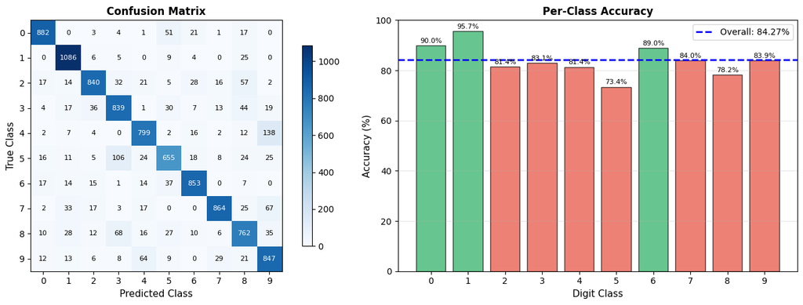

```
======================================================================
Analysis Summary:
======================================================================
Overall Accuracy: 84.27%
Best performing digit: 1 (95.68%)
Worst performing digit: 5 (73.43%)

Note: Modern deep networks achieve >99% accuracy on MNIST.
The Naive Bayes classifier's lower accuracy (~84%) is due to the
incorrect assumption that pixels are conditionally independent.
======================================================================
```

```python
# Step 6: Detailed Analysis - Confusion Matrix and Per-Class Accuracy
print("\n[Step 6] Detailed Analysis...")

# Compute confusion matrix
confusion_matrix = torch.zeros((n_classes, n_classes), dtype=torch.int32)
for i in range(total):
    true_label = Y_test[i].item()
    pred_label = predictions[i].item()
    confusion_matrix[true_label, pred_label] += 1

# Per-class accuracy
per_class_accuracy = torch.zeros(n_classes)
for y in range(n_classes):
    class_total = (Y_test == y).sum().item()
    class_correct = confusion_matrix[y, y].item()
    per_class_accuracy[y] = class_correct / class_total if class_total > 0 else 0

print("\nPer-Class Accuracy:")
print("-" * 40)
for y in range(n_classes):
    print(f"  Digit {y}: {per_class_accuracy[y].item()*100:.2f}%")
print("-" * 40)

# Visualize confusion matrix
fig, axes = plt.subplots(1, 2, figsize=(14, 5))

# Confusion matrix heatmap
im = axes[0].imshow(confusion_matrix.numpy(), cmap='Blues')
axes[0].set_xlabel('Predicted Class', fontsize=11)
axes[0].set_ylabel('True Class', fontsize=11)
axes[0].set_title('Confusion Matrix', fontsize=12, fontweight='bold')
axes[0].set_xticks(range(n_classes))
axes[0].set_yticks(range(n_classes))
plt.colorbar(im, ax=axes[0], shrink=0.8)

# Add text annotations
for i in range(n_classes):
    for j in range(n_classes):
        val = confusion_matrix[i, j].item()
        color = 'white' if val > confusion_matrix.max().item() / 2 else 'black'
        axes[0].text(j, i, str(val), ha='center', va='center', fontsize=8, color=color)

# Per-class accuracy bar chart
colors = ['#27AE60' if acc > 0.85 else '#E74C3C' for acc in per_class_accuracy.numpy()]
axes[1].bar(range(n_classes), per_class_accuracy.numpy() * 100, color=colors, alpha=0.7, edgecolor='black')
axes[1].axhline(y=accuracy * 100, color='blue', linestyle='--', linewidth=2, label=f'Overall: {accuracy*100:.2f}%')
axes[1].set_xlabel('Digit Class', fontsize=11)
axes[1].set_ylabel('Accuracy (%)', fontsize=11)
axes[1].set_title('Per-Class Accuracy', fontsize=12, fontweight='bold')
axes[1].set_xticks(range(n_classes))
axes[1].set_ylim([0, 100])
axes[1].legend()
axes[1].grid(True, alpha=0.3, axis='y')

for i, v in enumerate(per_class_accuracy.numpy() * 100):
    axes[1].text(i, v + 1, f'{v:.1f}%', ha='center', fontsize=8)

plt.tight_layout()
plt.show()

print(f"\n{'='*70}")
print("Analysis Summary:")
print(f"{'='*70}")
print(f"Overall Accuracy: {accuracy*100:.2f}%")
print(f"Best performing digit: {torch.argmax(per_class_accuracy).item()} ({per_class_accuracy.max().item()*100:.2f}%)")
print(f"Worst performing digit: {torch.argmin(per_class_accuracy).item()} ({per_class_accuracy.min().item()*100:.2f}%)")
print(f"\nNote: Modern deep networks achieve >99% accuracy on MNIST.")
print(f"The Naive Bayes classifier's lower accuracy (~84%) is due to the")
print(f"incorrect assumption that pixels are conditionally independent.")
print(f"{'='*70}")
```

### 2.9. Visualizations for Naive Bayes

This section provides visual demonstrations of the Naive Bayes classifier, including:

1. **Class Distribution Histogram** - Prior probabilities
2. **Decision Boundary** - 2D classification regions
3. **Posterior Probability Heatmap** - Probability landscape

```
======================================================================
Naive Bayes Visualizations
======================================================================
```

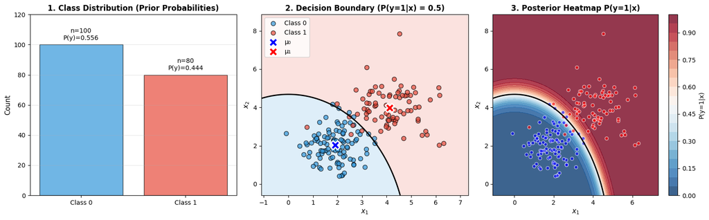

```
Visualization Summary:
  1. Histogram shows class imbalance and prior probabilities
  2. Decision boundary separates the two classes
  3. Heatmap shows probability gradient across feature space
```

```python
import numpy as np
import matplotlib.pyplot as plt
from matplotlib.colors import ListedColormap

print("="*70)
print("Naive Bayes Visualizations")
print("="*70)

# Generate synthetic 2D data for visualization
np.random.seed(42)

# Class 0: centered at (2, 2)
n0 = 100
X0 = np.random.randn(n0, 2) * 0.8 + np.array([2, 2])
y0 = np.zeros(n0)

# Class 1: centered at (4, 4)
n1 = 80
X1 = np.random.randn(n1, 2) * 1.0 + np.array([4, 4])
y1 = np.ones(n1)

# Combine
X = np.vstack([X0, X1])
y = np.hstack([y0, y1])

# Train Naive Bayes (Gaussian)
# Prior
P_y0 = n0 / (n0 + n1)
P_y1 = n1 / (n0 + n1)

# Class-conditional mean and std for each feature
mu0 = X0.mean(axis=0)
mu1 = X1.mean(axis=0)
std0 = X0.std(axis=0)
std1 = X1.std(axis=0)

def gaussian_pdf(x, mu, std):
    return np.exp(-0.5 * ((x - mu) / std) ** 2) / (std * np.sqrt(2 * np.pi))

def predict_proba(X):
    """Compute posterior probabilities for each class"""
    # P(x|y=0) = P(x1|y=0) * P(x2|y=0)  (naive assumption)
    likelihood_0 = gaussian_pdf(X[:, 0], mu0[0], std0[0]) * gaussian_pdf(X[:, 1], mu0[1], std0[1])
    likelihood_1 = gaussian_pdf(X[:, 0], mu1[0], std1[0]) * gaussian_pdf(X[:, 1], mu1[1], std1[1])

    # Posterior (unnormalized)
    post_0 = P_y0 * likelihood_0
    post_1 = P_y1 * likelihood_1

    # Normalize
    total = post_0 + post_1
    return post_0 / total, post_1 / total

# Create figure with 3 subplots
fig, axes = plt.subplots(1, 3, figsize=(16, 5))

# =====================================================
# Plot 1: Class Distribution Histogram (Prior)
# =====================================================
classes = ['Class 0', 'Class 1']
counts = [n0, n1]
priors = [P_y0, P_y1]

bars = axes[0].bar(classes, counts, color=['#3498DB', '#E74C3C'], alpha=0.7, edgecolor='black')
axes[0].set_ylabel('Count', fontsize=11)
axes[0].set_title('1. Class Distribution (Prior Probabilities)', fontsize=12, fontweight='bold')
axes[0].set_ylim([0, max(counts) * 1.2])
for i, (bar, count, prior) in enumerate(zip(bars, counts, priors)):
    axes[0].text(bar.get_x() + bar.get_width()/2, count + 3,
                f'n={count}\nP(y)={prior:.3f}', ha='center', fontsize=10)
axes[0].grid(True, alpha=0.3, axis='y')

# =====================================================
# Plot 2: Decision Boundary
# =====================================================
# Create mesh grid
x_min, x_max = X[:, 0].min() - 1, X[:, 0].max() + 1
y_min, y_max = X[:, 1].min() - 1, X[:, 1].max() + 1
xx, yy = np.meshgrid(np.linspace(x_min, x_max, 200),
                      np.linspace(y_min, y_max, 200))

# Predict on mesh
grid_points = np.c_[xx.ravel(), yy.ravel()]
_, prob_1 = predict_proba(grid_points)
Z = (prob_1 > 0.5).reshape(xx.shape)

# Plot decision regions
cmap_light = ListedColormap(['#AED6F1', '#F5B7B1'])
axes[1].contourf(xx, yy, Z, alpha=0.4, cmap=cmap_light)
axes[1].contour(xx, yy, prob_1.reshape(xx.shape), levels=[0.5], colors='black', linewidths=2)

# Plot data points
axes[1].scatter(X0[:, 0], X0[:, 1], c='#3498DB', edgecolors='black', s=50, label='Class 0', alpha=0.7)
axes[1].scatter(X1[:, 0], X1[:, 1], c='#E74C3C', edgecolors='black', s=50, label='Class 1', alpha=0.7)
axes[1].scatter(*mu0, c='blue', marker='X', s=200, edgecolors='white', linewidths=2, label='μ₀')
axes[1].scatter(*mu1, c='red', marker='X', s=200, edgecolors='white', linewidths=2, label='μ₁')

axes[1].set_xlabel('$x_1$', fontsize=11)
axes[1].set_ylabel('$x_2$', fontsize=11)
axes[1].set_title('2. Decision Boundary (P(y=1|x) = 0.5)', fontsize=12, fontweight='bold')
axes[1].legend(loc='upper left')

# =====================================================
# Plot 3: Posterior Probability Heatmap
# =====================================================
prob_1_grid = prob_1.reshape(xx.shape)
im = axes[2].contourf(xx, yy, prob_1_grid, levels=20, cmap='RdBu_r', alpha=0.8)
axes[2].contour(xx, yy, prob_1_grid, levels=[0.5], colors='black', linewidths=2)

# Plot data points
axes[2].scatter(X0[:, 0], X0[:, 1], c='blue', edgecolors='white', s=30, alpha=0.6)
axes[2].scatter(X1[:, 0], X1[:, 1], c='red', edgecolors='white', s=30, alpha=0.6)

axes[2].set_xlabel('$x_1$', fontsize=11)
axes[2].set_ylabel('$x_2$', fontsize=11)
axes[2].set_title('3. Posterior Heatmap P(y=1|x)', fontsize=12, fontweight='bold')
plt.colorbar(im, ax=axes[2], label='P(y=1|x)')

plt.tight_layout()
plt.show()

print("\nVisualization Summary:")
print("  1. Histogram shows class imbalance and prior probabilities")
print("  2. Decision boundary separates the two classes")
print("  3. Heatmap shows probability gradient across feature space")
```

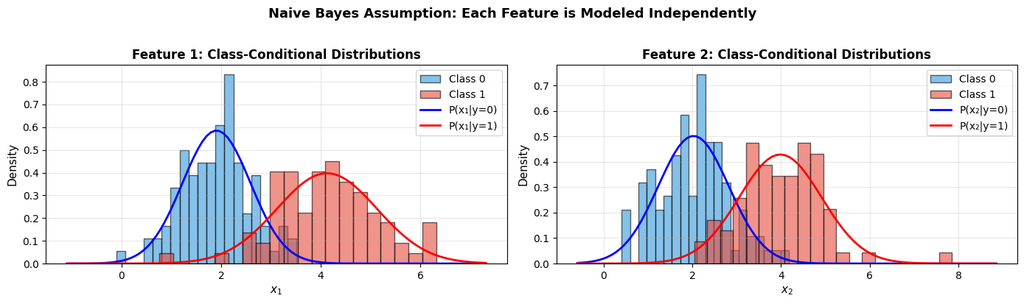

```
Key Insight: Naive Bayes models each feature P(x_j|y) independently,
then multiplies them together: P(x|y) = P(x₁|y) × P(x₂|y)
```

```python
# Additional visualization: Feature distributions per class
fig, axes = plt.subplots(1, 2, figsize=(14, 4))

# Feature 1 distribution
axes[0].hist(X0[:, 0], bins=20, alpha=0.6, color='#3498DB', label='Class 0', density=True, edgecolor='black')
axes[0].hist(X1[:, 0], bins=20, alpha=0.6, color='#E74C3C', label='Class 1', density=True, edgecolor='black')

# Plot Gaussian fits
x_range = np.linspace(X[:, 0].min() - 1, X[:, 0].max() + 1, 100)
axes[0].plot(x_range, gaussian_pdf(x_range, mu0[0], std0[0]), 'b-', linewidth=2, label=f'P(x₁|y=0)')
axes[0].plot(x_range, gaussian_pdf(x_range, mu1[0], std1[0]), 'r-', linewidth=2, label=f'P(x₁|y=1)')

axes[0].set_xlabel('$x_1$', fontsize=11)
axes[0].set_ylabel('Density', fontsize=11)
axes[0].set_title('Feature 1: Class-Conditional Distributions', fontsize=12, fontweight='bold')
axes[0].legend()
axes[0].grid(True, alpha=0.3)

# Feature 2 distribution
axes[1].hist(X0[:, 1], bins=20, alpha=0.6, color='#3498DB', label='Class 0', density=True, edgecolor='black')
axes[1].hist(X1[:, 1], bins=20, alpha=0.6, color='#E74C3C', label='Class 1', density=True, edgecolor='black')

# Plot Gaussian fits
x_range = np.linspace(X[:, 1].min() - 1, X[:, 1].max() + 1, 100)
axes[1].plot(x_range, gaussian_pdf(x_range, mu0[1], std0[1]), 'b-', linewidth=2, label=f'P(x₂|y=0)')
axes[1].plot(x_range, gaussian_pdf(x_range, mu1[1], std1[1]), 'r-', linewidth=2, label=f'P(x₂|y=1)')

axes[1].set_xlabel('$x_2$', fontsize=11)
axes[1].set_ylabel('Density', fontsize=11)
axes[1].set_title('Feature 2: Class-Conditional Distributions', fontsize=12, fontweight='bold')
axes[1].legend()
axes[1].grid(True, alpha=0.3)

plt.suptitle('Naive Bayes Assumption: Each Feature is Modeled Independently', fontsize=13, fontweight='bold', y=1.02)
plt.tight_layout()
plt.show()

print("\nKey Insight: Naive Bayes models each feature P(x_j|y) independently,")
print("then multiplies them together: P(x|y) = P(x₁|y) × P(x₂|y)")
```

## 3. Summary

In this notebook, we have covered the complete theory and implementation of the **Naive Bayes classifier** as presented in D2L Chapter 22.9. Here are the key takeaways:

### 3.1. Key Formulas

| Formula | Description |
| --- | --- |
| $\hat{y} = \operatorname*{argmax}_y P(y \mid \mathbf{x})$ | Classification rule (22.9.1) |
| $P(y \mid \mathbf{x}) = \frac{P(\mathbf{x} \mid y)P(y)}{P(\mathbf{x})}$ | Bayes' theorem (22.9.2) |
| $P(\mathbf{x} \mid y) = \prod_{i=1}^{d} P(x_i \mid y)$ | Naive independence assumption (22.9.4) |
| $P(x_i = t_i \mid y) = P_{xy}[i,y]^{t_i}(1-P_{xy}[i,y])^{1-t_i}$ | Binary feature model (22.9.5-6) |
| $\hat{y} = \operatorname*{argmax}_y \left[\log P_y[y] + \sum_i \left[t_i \log P_{xy}[i,y] + (1-t_i)\log(1-P_{xy}[i,y])\right]\right]$ | Log-probability form (22.9.7) |

### 3.2. Key Insights

1. **Using Bayes' rule**, a classifier can be constructed by assuming all observed features are **conditionally independent** given the class label.
2. **Training** the classifier involves counting occurrences of combinations of labels and feature values in the training data.
3. **Laplace smoothing** prevents zero probabilities by adding pseudo-counts, which is essential when some feature values never appear for certain classes.
4. The **logarithmic form** is crucial for numerical stability when working with high-dimensional data (e.g., 784 pixels in MNIST).
5. Despite its simplicity and the "naive" independence assumption, this classifier was the **gold standard for decades** for tasks such as spam detection.
6. The relatively poor performance on MNIST (~84% accuracy compared to >99% for deep networks) demonstrates the **limitation of the independence assumption** - in reality, neighboring pixels in images are highly correlated.

### 3.3. Practical Considerations

- **Pros:** Simple, fast, interpretable, works well with limited training data
- **Cons:** Independence assumption is often violated, leading to suboptimal performance on complex data

[figure not shown]

```
======================================================================
Exercise 1 - Framework Comparison
======================================================================
Features: x1=1, x2=0

Unnormalized Posteriors:
  NumPy:      Class 0=0.096000, Class 1=0.108000
  PyTorch:    Class 0=0.096000, Class 1=0.108000
  TensorFlow: Class 0=0.096000, Class 1=0.108000

Normalized Posteriors:
  Class 0: 0.470588 (47.06%)
  Class 1: 0.529412 (52.94%)

Predicted: Class 1
======================================================================
```

```python
import numpy as np
import torch
import tensorflow as tf
import matplotlib.pyplot as plt

# Exercise 1 data
P_y_data = [0.4, 0.6]
P_xy_data = [[0.8, 0.7], [0.3, 0.4]]  # P(xi=1|y)
test_features = [1, 0]  # x1=1, x2=0
class_labels = ['Class 0', 'Class 1']

# Compute posteriors for all frameworks
def compute_posteriors(P_y, P_xy, features):
    posteriors = []
    for cls in range(len(P_y)):
        prob = P_y[cls]
        for i, feature in enumerate(features):
            if feature == 1:
                prob *= P_xy[cls][i]
            else:
                prob *= (1 - P_xy[cls][i])
        posteriors.append(prob)
    return posteriors

# NumPy
posteriors_np = np.array(compute_posteriors(P_y_data, P_xy_data, test_features))

# PyTorch
P_y_torch = torch.tensor(P_y_data, dtype=torch.float32)
P_xy_torch = torch.tensor(P_xy_data, dtype=torch.float32)
posteriors_torch = torch.tensor(compute_posteriors(P_y_data, P_xy_data, test_features), dtype=torch.float32)

# TensorFlow
posteriors_tf = tf.constant(compute_posteriors(P_y_data, P_xy_data, test_features), dtype=tf.float32)

# Normalize posteriors
total_np = posteriors_np.sum()
normalized_np = posteriors_np / total_np

# Create 2x2 visualization
fig, axes = plt.subplots(2, 2, figsize=(14, 10))
colors = ['#FF9999', '#99CCFF']

# NumPy - Unnormalized
axes[0,0].bar(class_labels, posteriors_np, color=colors, alpha=0.7, edgecolor='black', linewidth=2)
axes[0,0].set_title('NumPy - Unnormalized Posteriors', fontsize=12, fontweight='bold')
axes[0,0].set_ylabel('Probability', fontsize=10)
axes[0,0].set_ylim([0, max(posteriors_np) * 1.3])
for i, v in enumerate(posteriors_np):
    axes[0,0].text(i, v + 0.005, f'{v:.4f}', ha='center', va='bottom', fontsize=10, fontweight='bold')
axes[0,0].grid(True, alpha=0.3, axis='y')

# PyTorch - Unnormalized
axes[0,1].bar(class_labels, posteriors_torch.numpy(), color=colors, alpha=0.7, edgecolor='black', linewidth=2)
axes[0,1].set_title('PyTorch - Unnormalized Posteriors', fontsize=12, fontweight='bold')
axes[0,1].set_ylabel('Probability', fontsize=10)
axes[0,1].set_ylim([0, max(posteriors_torch.numpy()) * 1.3])
for i, v in enumerate(posteriors_torch.numpy()):
    axes[0,1].text(i, v + 0.005, f'{v:.4f}', ha='center', va='bottom', fontsize=10, fontweight='bold')
axes[0,1].grid(True, alpha=0.3, axis='y')

# TensorFlow - Unnormalized
axes[1,0].bar(class_labels, posteriors_tf.numpy(), color=colors, alpha=0.7, edgecolor='black', linewidth=2)
axes[1,0].set_title('TensorFlow - Unnormalized Posteriors', fontsize=12, fontweight='bold')
axes[1,0].set_ylabel('Probability', fontsize=10)
axes[1,0].set_ylim([0, max(posteriors_tf.numpy()) * 1.3])
for i, v in enumerate(posteriors_tf.numpy()):
    axes[1,0].text(i, v + 0.005, f'{v:.4f}', ha='center', va='bottom', fontsize=10, fontweight='bold')
axes[1,0].grid(True, alpha=0.3, axis='y')

# NumPy - Normalized (for consistent 2x2 layout)
axes[1,1].bar(class_labels, normalized_np, color=colors, alpha=0.7, edgecolor='black', linewidth=2)
axes[1,1].set_title('NumPy - Normalized Posteriors', fontsize=12, fontweight='bold')
axes[1,1].set_ylabel('Probability', fontsize=10)
axes[1,1].set_ylim([0, max(normalized_np) * 1.3])
for i, v in enumerate(normalized_np):
    axes[1,1].text(i, v + 0.005, f'{v:.4f}', ha='center', va='bottom', fontsize=10, fontweight='bold')
axes[1,1].grid(True, alpha=0.3, axis='y')

plt.suptitle(f'Exercise 1: Binary Classification (x1={test_features[0]}, x2={test_features[1]})', fontsize=14, fontweight='bold')
plt.tight_layout()
plt.show()

print(f"\n{'='*70}")
print(f"Exercise 1 - Framework Comparison")
print(f"{'='*70}")
print(f"Features: x1={test_features[0]}, x2={test_features[1]}")
print(f"\nUnnormalized Posteriors:")
print(f"  NumPy:      Class 0={posteriors_np[0]:.6f}, Class 1={posteriors_np[1]:.6f}")
print(f"  PyTorch:    Class 0={posteriors_torch[0].item():.6f}, Class 1={posteriors_torch[1].item():.6f}")
print(f"  TensorFlow: Class 0={posteriors_tf[0].numpy():.6f}, Class 1={posteriors_tf[1].numpy():.6f}")
print(f"\nNormalized Posteriors:")
print(f"  Class 0: {normalized_np[0]:.6f} ({normalized_np[0]:.2%})")
print(f"  Class 1: {normalized_np[1]:.6f} ({normalized_np[1]:.2%})")
print(f"\nPredicted: Class {np.argmax(posteriors_np)}")
print(f"{'='*70}")
```

## 4. Exercise Solutions

This section provides detailed solutions to all exercises from D2L Chapter 22.9.6, including:

- **Detailed reasoning:** Clear mathematical derivations
- **Computations:** All calculation steps shown explicitly
- **Python implementation:** Numerical verification of analytical results

The exercises from the textbook are:

1. **XOR Problem:** Analyze Naive Bayes on XOR dataset
2. **Laplace Smoothing:** What happens without smoothing when encountering unseen values?
3. **Bayesian Networks:** Explain how dependence structure enables XOR classification

### Exercise 1: XOR Problem

**Problem Statement:**

Consider the dataset $[[0,0], [0,1], [1,0], [1,1]]$ with labels given by the XOR of the two elements $[0, 1, 1, 0]$. What are the probabilities for a Naive Bayes classifier built on this dataset? Does it successfully classify our points? If not, what assumptions are violated?

### Detailed Solution:

**Step 1: Compute Prior Probabilities**

From the dataset:

- Class 0: appears at $[0,0]$ and $[1,1]$ → $n_0 = 2$
- Class 1: appears at $[0,1]$ and $[1,0]$ → $n_1 = 2$
- Total: $n = 4$

$$ P(y=0) = \frac{2}{4} = 0.5, \quad P(y=1) = \frac{2}{4} = 0.5 $$

**Step 2: Compute Conditional Probabilities**

For class $y = 0$ (points $[0,0]$ and $[1,1]$):

- $x_1 = 1$ appears in 1 out of 2 cases: $P(x_1=1|y=0) = \frac{1}{2} = 0.5$
- $x_2 = 1$ appears in 1 out of 2 cases: $P(x_2=1|y=0) = \frac{1}{2} = 0.5$

For class $y = 1$ (points $[0,1]$ and $[1,0]$):

- $x_1 = 1$ appears in 1 out of 2 cases: $P(x_1=1|y=1) = \frac{1}{2} = 0.5$
- $x_2 = 1$ appears in 1 out of 2 cases: $P(x_2=1|y=1) = \frac{1}{2} = 0.5$

**Step 3: Classification Attempt**

For any input $\mathbf{x} = [x_1, x_2]$:

$$ P(y=0|\mathbf{x}) \propto P(y=0) \cdot P(x_1|y=0) \cdot P(x_2|y=0) = 0.5 \cdot P(x_1|y=0) \cdot P(x_2|y=0) $$

$$ P(y=1|\mathbf{x}) \propto P(y=1) \cdot P(x_1|y=1) \cdot P(x_2|y=1) = 0.5 \cdot P(x_1|y=1) \cdot P(x_2|y=1) $$

Since $P(x_i=t|y=0) = P(x_i=t|y=1) = 0.5$ for all $t \in \{0,1\}$:

$$ P(y=0|\mathbf{x}) = P(y=1|\mathbf{x}) = 0.5 \quad \text{for ALL inputs!} $$

**Step 4: Conclusion**

**The Naive Bayes classifier FAILS on XOR!** It predicts 50-50 for every input, achieving only **50% accuracy** (random guessing).

**Why does it fail?** The **conditional independence assumption is violated**. In XOR:

- $x_1$ and $x_2$ are **not independent** given the class $y$
- The output depends on the **interaction** between $x_1$ and $x_2$, not on each feature independently
- XOR is defined as $y = x_1 \oplus x_2$ (exclusive OR), which requires considering both features together

### Python Verification:

```
======================================================================
Exercise 1: XOR Problem - Naive Bayes Analysis
======================================================================

XOR Dataset:
------------------------------
  x = [0 0] → y = 0
  x = [0 1] → y = 1
  x = [1 0] → y = 1
  x = [1 1] → y = 0
------------------------------

Step 1: Prior Probabilities
  P(y=0) = 2/4 = 0.5000
  P(y=1) = 2/4 = 0.5000

Step 2: Conditional Probabilities
  For class y=0 (points [0,0] and [1,1]):
    P(x1=1|y=0) = 0.5000
    P(x2=1|y=0) = 0.5000
  For class y=1 (points [0,1] and [1,0]):
    P(x1=1|y=1) = 0.5000
    P(x2=1|y=1) = 0.5000

Step 3: Classification Results
--------------------------------------------------
  x=[0 0] → P(y=0|x)=0.5000, P(y=1|x)=0.5000 → Pred=0, True=0 ✓
  x=[0 1] → P(y=0|x)=0.5000, P(y=1|x)=0.5000 → Pred=0, True=1 ✗
  x=[1 0] → P(y=0|x)=0.5000, P(y=1|x)=0.5000 → Pred=0, True=1 ✗
  x=[1 1] → P(y=0|x)=0.5000, P(y=1|x)=0.5000 → Pred=0, True=0 ✓
--------------------------------------------------

Accuracy: 2/4 = 50.00%
```

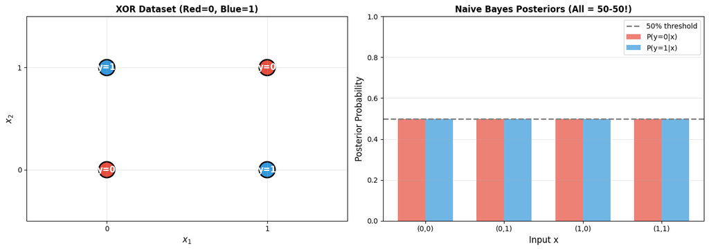

```
======================================================================
CONCLUSION: Naive Bayes FAILS on XOR!
All posteriors are 50-50, resulting in random guessing.
The conditional independence assumption is violated.
======================================================================
```

```python
import numpy as np
import torch
import matplotlib.pyplot as plt

print("="*70)
print("Exercise 1: XOR Problem - Naive Bayes Analysis")
print("="*70)

# XOR Dataset
X = np.array([[0, 0], [0, 1], [1, 0], [1, 1]])
y = np.array([0, 1, 1, 0])  # XOR labels

print("\nXOR Dataset:")
print("-" * 30)
for i in range(len(X)):
    print(f"  x = {X[i]} → y = {y[i]}")
print("-" * 30)

# Step 1: Compute Prior Probabilities
n_0 = (y == 0).sum()
n_1 = (y == 1).sum()
n = len(y)

P_y = {0: n_0 / n, 1: n_1 / n}
print(f"\nStep 1: Prior Probabilities")
print(f"  P(y=0) = {n_0}/{n} = {P_y[0]:.4f}")
print(f"  P(y=1) = {n_1}/{n} = {P_y[1]:.4f}")

# Step 2: Compute Conditional Probabilities
P_xy = {0: [], 1: []}

for cls in [0, 1]:
    X_cls = X[y == cls]  # Data points for this class
    for feature_idx in range(2):
        prob = X_cls[:, feature_idx].mean()  # P(x_i = 1 | y = cls)
        P_xy[cls].append(prob)

print(f"\nStep 2: Conditional Probabilities")
print(f"  For class y=0 (points [0,0] and [1,1]):")
print(f"    P(x1=1|y=0) = {P_xy[0][0]:.4f}")
print(f"    P(x2=1|y=0) = {P_xy[0][1]:.4f}")
print(f"  For class y=1 (points [0,1] and [1,0]):")
print(f"    P(x1=1|y=1) = {P_xy[1][0]:.4f}")
print(f"    P(x2=1|y=1) = {P_xy[1][1]:.4f}")

# Step 3: Classify all points
print(f"\nStep 3: Classification Results")
print("-" * 50)
correct = 0
results = []

for i in range(len(X)):
    x = X[i]
    posteriors = {}
    for cls in [0, 1]:
        prob = P_y[cls]
        for j in range(2):
            if x[j] == 1:
                prob *= P_xy[cls][j]
            else:
                prob *= (1 - P_xy[cls][j])
        posteriors[cls] = prob

    # Normalize
    total = posteriors[0] + posteriors[1]
    posteriors_norm = {0: posteriors[0]/total, 1: posteriors[1]/total}

    pred = 0 if posteriors[0] >= posteriors[1] else 1
    true_label = y[i]
    is_correct = pred == true_label
    correct += is_correct
    results.append((x, true_label, pred, posteriors_norm[0], posteriors_norm[1], is_correct))

    status = "✓" if is_correct else "✗"
    print(f"  x={x} → P(y=0|x)={posteriors_norm[0]:.4f}, P(y=1|x)={posteriors_norm[1]:.4f} → Pred={pred}, True={true_label} {status}")

print("-" * 50)
accuracy = correct / len(X)
print(f"\nAccuracy: {correct}/{len(X)} = {accuracy:.2%}")

# Visualization
fig, axes = plt.subplots(1, 2, figsize=(14, 5))

# XOR data visualization
colors_data = ['#E74C3C' if label == 0 else '#3498DB' for label in y]
axes[0].scatter(X[:, 0], X[:, 1], c=colors_data, s=500, edgecolors='black', linewidth=2)
for i, (xi, label) in enumerate(zip(X, y)):
    axes[0].annotate(f'y={label}', (xi[0], xi[1]), fontsize=12, ha='center', va='center', fontweight='bold', color='white')
axes[0].set_xlabel('$x_1$', fontsize=12)
axes[0].set_ylabel('$x_2$', fontsize=12)
axes[0].set_title('XOR Dataset (Red=0, Blue=1)', fontsize=12, fontweight='bold')
axes[0].set_xlim([-0.5, 1.5])
axes[0].set_ylim([-0.5, 1.5])
axes[0].set_xticks([0, 1])
axes[0].set_yticks([0, 1])
axes[0].grid(True, alpha=0.3)

# Posterior probabilities for each point
x_labels = [f'({xi[0]},{xi[1]})' for xi in X]
p_class0 = [r[3] for r in results]
p_class1 = [r[4] for r in results]

x_pos = np.arange(len(X))
width = 0.35

bars1 = axes[1].bar(x_pos - width/2, p_class0, width, label='P(y=0|x)', color='#E74C3C', alpha=0.7)
bars2 = axes[1].bar(x_pos + width/2, p_class1, width, label='P(y=1|x)', color='#3498DB', alpha=0.7)

axes[1].axhline(y=0.5, color='gray', linestyle='--', linewidth=2, label='50% threshold')
axes[1].set_xlabel('Input x', fontsize=12)
axes[1].set_ylabel('Posterior Probability', fontsize=12)
axes[1].set_title('Naive Bayes Posteriors (All = 50-50!)', fontsize=12, fontweight='bold')
axes[1].set_xticks(x_pos)
axes[1].set_xticklabels(x_labels)
axes[1].legend()
axes[1].set_ylim([0, 1])
axes[1].grid(True, alpha=0.3, axis='y')

plt.tight_layout()
plt.show()

print(f"\n{'='*70}")
print("CONCLUSION: Naive Bayes FAILS on XOR!")
print("All posteriors are 50-50, resulting in random guessing.")
print("The conditional independence assumption is violated.")
print(f"{'='*70}")
```

```python
# Additional verification using PyTorch
import torch

# Convert to tensors
X_torch = torch.tensor([[0, 0], [0, 1], [1, 0], [1, 1]], dtype=torch.float32)
y_torch = torch.tensor([0, 1, 1, 0], dtype=torch.int64)

# Compute probabilities using PyTorch
P_y_torch = torch.zeros(2)
for c in range(2):
    P_y_torch[c] = (y_torch == c).float().mean()

P_xy_torch = torch.zeros(2, 2)  # [class, feature]
for c in range(2):
    mask = y_torch == c
    P_xy_torch[c] = X_torch[mask].mean(dim=0)

print("PyTorch Verification:")
print(f"  P(y=0) = {P_y_torch[0].item():.4f}, P(y=1) = {P_y_torch[1].item():.4f}")
print(f"  P(x1=1|y=0) = {P_xy_torch[0,0].item():.4f}, P(x2=1|y=0) = {P_xy_torch[0,1].item():.4f}")
print(f"  P(x1=1|y=1) = {P_xy_torch[1,0].item():.4f}, P(x2=1|y=1) = {P_xy_torch[1,1].item():.4f}")
print("\nAll probabilities are 0.5 - confirming Naive Bayes cannot distinguish classes!")
```

```
PyTorch Verification:
  P(y=0) = 0.5000, P(y=1) = 0.5000
  P(x1=1|y=0) = 0.5000, P(x2=1|y=0) = 0.5000
  P(x1=1|y=1) = 0.5000, P(x2=1|y=1) = 0.5000

All probabilities are 0.5 - confirming Naive Bayes cannot distinguish classes!
```

**Python code confirms that Naive Bayes fails on XOR with 50% accuracy (random guessing).**

### Key Takeaways from Exercise 1:

1. **XOR is not linearly separable** - you cannot draw a single line to separate the classes
2. **The naive independence assumption is violated** - in XOR, the label depends on the **interaction** between $x_1$ and $x_2$, not on each feature independently
3. **Each feature individually provides no information** - $P(x_i=1|y=0) = P(x_i=1|y=1) = 0.5$ for both features
4. **This is a fundamental limitation** of Naive Bayes, not a bug in the implementation

### Exercise 2: Laplace Smoothing

**Problem Statement:**

Suppose that we did not use Laplace smoothing when estimating probabilities and a data example arrived at testing time which contained a value never observed in training. What would the model output?

### Detailed Solution:

**Step 1: Understanding the Problem**

Without Laplace smoothing, we estimate:

$$ \hat{P}_{xy}[i, y] = \frac{n_{iy}}{n_y} $$

If a feature value was **never observed** for a particular class during training, then $n_{iy} = 0$, giving:

$$ \hat{P}_{xy}[i, y] = \frac{0}{n_y} = 0 $$

**Step 2: The Catastrophic Consequence**

When we compute the likelihood for classification:

$$ P(\mathbf{x}|y) = \prod_{i=1}^{d} P(x_i|y) $$

If even **ONE** term in the product is zero, the entire product becomes zero:

$$ P(\mathbf{x}|y) = \ldots \times 0 \times \ldots = 0 $$

**Step 3: Classification Failure**

This leads to several failure modes:

1. **Division by zero:** If $P(\mathbf{x}|y) = 0$ for all classes, computing $P(y|\mathbf{x})$ involves dividing by zero
2. **Arbitrary classification:** If $P(\mathbf{x}|y) = 0$ for some classes but not others, those classes are completely ruled out, even if all evidence except one feature supports that class
3. **Log-domain issues:** Taking $\log(0) = -\infty$ causes numerical errors

**Step 4: Concrete Example**

Consider classifying an email with a word "cryptocurrency" that never appeared in the training spam corpus:

- Training data: 1000 spam emails, 0 contain "cryptocurrency"
- Without smoothing: $P(\text{"cryptocurrency"}|\text{Spam}) = 0/1000 = 0$
- Result: **Any email with "cryptocurrency" is classified as Not Spam**, regardless of other evidence!

**Step 5: Laplace Smoothing Solution**

With Laplace smoothing:

$$ \hat{P}_{xy}[i, y] = \frac{n_{iy} + 1}{n_y + 2} = \frac{0 + 1}{1000 + 2} = \frac{1}{1002} \approx 0.001 $$

Now the probability is small but non-zero, allowing the classifier to still consider other features.

### Python Demonstration:

```
======================================================================
Exercise 2: Laplace Smoothing Demonstration
======================================================================

Training Data:
  Spam emails: 1000, containing 'cryptocurrency': 0
  Not-spam emails: 5000, containing 'cryptocurrency': 50

--- Without Laplace Smoothing ---
P('cryptocurrency'|Spam) = 0/1000 = 0.0
P('cryptocurrency'|Not Spam) = 50/5000 = 0.01

--- With Laplace Smoothing ---
P('cryptocurrency'|Spam) = (0+1)/(1000+2) = 0.000998
P('cryptocurrency'|Not Spam) = (50+1)/(5000+2) = 0.010196

--- Classification of email with 'cryptocurrency' ---

Priors: P(Spam)=0.1667, P(Not Spam)=0.8333

Without Smoothing:
  P(Spam|x) ∝ 0.1667 × 0.0 = 0.0
  P(Not Spam|x) ∝ 0.8333 × 0.01 = 0.008333333333333333
  → Spam probability = 0%! (ALWAYS classifies as Not Spam)

With Laplace Smoothing:
  P(Spam|x) ∝ 0.1667 × 0.000998 = 0.000166
  P(Not Spam|x) ∝ 0.8333 × 0.010196 = 0.008497
  → Spam probability = 1.92%
```

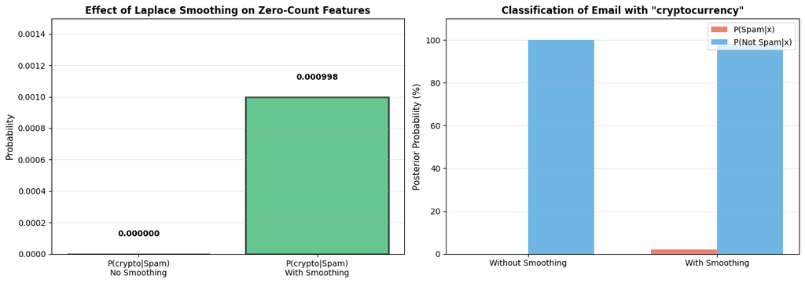

```
======================================================================
CONCLUSION: Without Laplace smoothing, unseen features cause zero
probabilities, leading to incorrect classifications.
Laplace smoothing prevents this by adding pseudo-counts.
======================================================================
```

```python
import numpy as np
import matplotlib.pyplot as plt

print("="*70)
print("Exercise 2: Laplace Smoothing Demonstration")
print("="*70)

# Simulate training data for spam classification
# Feature: word "cryptocurrency" appears
n_spam = 1000  # Total spam emails in training
n_crypto_in_spam = 0  # "cryptocurrency" never appeared in spam during training

n_not_spam = 5000  # Total not-spam emails
n_crypto_in_not_spam = 50  # "cryptocurrency" appeared 50 times in not-spam

print("\nTraining Data:")
print(f"  Spam emails: {n_spam}, containing 'cryptocurrency': {n_crypto_in_spam}")
print(f"  Not-spam emails: {n_not_spam}, containing 'cryptocurrency': {n_crypto_in_not_spam}")

# Without Laplace smoothing
P_crypto_given_spam_no_smooth = n_crypto_in_spam / n_spam
P_crypto_given_not_spam_no_smooth = n_crypto_in_not_spam / n_not_spam

print("\n--- Without Laplace Smoothing ---")
print(f"P('cryptocurrency'|Spam) = {n_crypto_in_spam}/{n_spam} = {P_crypto_given_spam_no_smooth}")
print(f"P('cryptocurrency'|Not Spam) = {n_crypto_in_not_spam}/{n_not_spam} = {P_crypto_given_not_spam_no_smooth}")

# With Laplace smoothing
P_crypto_given_spam_smooth = (n_crypto_in_spam + 1) / (n_spam + 2)
P_crypto_given_not_spam_smooth = (n_crypto_in_not_spam + 1) / (n_not_spam + 2)

print("\n--- With Laplace Smoothing ---")
print(f"P('cryptocurrency'|Spam) = ({n_crypto_in_spam}+1)/({n_spam}+2) = {P_crypto_given_spam_smooth:.6f}")
print(f"P('cryptocurrency'|Not Spam) = ({n_crypto_in_not_spam}+1)/({n_not_spam}+2) = {P_crypto_given_not_spam_smooth:.6f}")

# Demonstrate the problem
print("\n--- Classification of email with 'cryptocurrency' ---")
P_spam = n_spam / (n_spam + n_not_spam)
P_not_spam = n_not_spam / (n_spam + n_not_spam)

print(f"\nPriors: P(Spam)={P_spam:.4f}, P(Not Spam)={P_not_spam:.4f}")

# Without smoothing
posterior_spam_no_smooth = P_spam * P_crypto_given_spam_no_smooth
posterior_not_spam_no_smooth = P_not_spam * P_crypto_given_not_spam_no_smooth

print("\nWithout Smoothing:")
print(f"  P(Spam|x) ∝ {P_spam:.4f} × {P_crypto_given_spam_no_smooth} = {posterior_spam_no_smooth}")
print(f"  P(Not Spam|x) ∝ {P_not_spam:.4f} × {P_crypto_given_not_spam_no_smooth} = {posterior_not_spam_no_smooth}")
print(f"  → Spam probability = 0%! (ALWAYS classifies as Not Spam)")

# With smoothing
posterior_spam_smooth = P_spam * P_crypto_given_spam_smooth
posterior_not_spam_smooth = P_not_spam * P_crypto_given_not_spam_smooth
total = posterior_spam_smooth + posterior_not_spam_smooth

print("\nWith Laplace Smoothing:")
print(f"  P(Spam|x) ∝ {P_spam:.4f} × {P_crypto_given_spam_smooth:.6f} = {posterior_spam_smooth:.6f}")
print(f"  P(Not Spam|x) ∝ {P_not_spam:.4f} × {P_crypto_given_not_spam_smooth:.6f} = {posterior_not_spam_smooth:.6f}")
print(f"  → Spam probability = {100*posterior_spam_smooth/total:.2f}%")

# Visualization
fig, axes = plt.subplots(1, 2, figsize=(14, 5))

# Bar chart comparison
categories = ['P(crypto|Spam)\nNo Smoothing', 'P(crypto|Spam)\nWith Smoothing']
values = [P_crypto_given_spam_no_smooth, P_crypto_given_spam_smooth]
colors = ['#E74C3C', '#27AE60']

axes[0].bar(categories, values, color=colors, alpha=0.7, edgecolor='black', linewidth=2)
axes[0].set_ylabel('Probability', fontsize=11)
axes[0].set_title('Effect of Laplace Smoothing on Zero-Count Features', fontsize=12, fontweight='bold')
axes[0].set_ylim([0, max(values) * 1.5 if max(values) > 0 else 0.01])
for i, v in enumerate(values):
    axes[0].text(i, v + 0.0001, f'{v:.6f}', ha='center', va='bottom', fontsize=10, fontweight='bold')
axes[0].grid(True, alpha=0.3, axis='y')

# Posterior comparison
posteriors = [
    ['No Smoothing', posterior_spam_no_smooth, posterior_not_spam_no_smooth],
    ['With Smoothing', posterior_spam_smooth, posterior_not_spam_smooth]
]

x = np.arange(2)
width = 0.35
bars1 = axes[1].bar(x - width/2, [0, posterior_spam_smooth/total*100], width, label='P(Spam|x)', color='#E74C3C', alpha=0.7)
bars2 = axes[1].bar(x + width/2, [100, posterior_not_spam_smooth/total*100], width, label='P(Not Spam|x)', color='#3498DB', alpha=0.7)

axes[1].set_ylabel('Posterior Probability (%)', fontsize=11)
axes[1].set_title('Classification of Email with "cryptocurrency"', fontsize=12, fontweight='bold')
axes[1].set_xticks(x)
axes[1].set_xticklabels(['Without Smoothing', 'With Smoothing'])
axes[1].legend()
axes[1].set_ylim([0, 110])
axes[1].grid(True, alpha=0.3, axis='y')

plt.tight_layout()
plt.show()

print(f"\n{'='*70}")
print("CONCLUSION: Without Laplace smoothing, unseen features cause zero")
print("probabilities, leading to incorrect classifications.")
print("Laplace smoothing prevents this by adding pseudo-counts.")
print(f"{'='*70}")
```

**Python code confirms that without Laplace smoothing, zero-count features cause classification failures.**

### Key Takeaways from Exercise 2:

1. **Zero probabilities are catastrophic** - they completely override all other evidence
2. **Laplace smoothing is essential** for robust Naive Bayes classifiers
3. **The Bayesian interpretation** provides principled justification: we're using a Beta(1,1) prior
4. **The smoothing strength can be tuned** - using different pseudo-counts (e.g., 0.5 instead of 1)

### Exercise 3: Bayesian Networks

**Problem Statement:**

The naive Bayes classifier is a specific example of a Bayesian network, where the dependence of random variables is encoded with a graph structure. While the full theory is beyond the scope of this section (see Koller and Friedman, 2009 for full details), explain why allowing explicit dependence between the two input variables in the XOR model allows for the creation of a successful classifier.

### Detailed Solution:

**Step 1: Understanding Bayesian Networks**

A Bayesian network is a directed acyclic graph (DAG) that represents conditional dependencies between random variables. Each node represents a variable, and edges represent direct probabilistic dependencies.

**Step 2: Naive Bayes as a Bayesian Network**

In Naive Bayes, the graph structure is:

```
    y (class)
   / \\
  ↓   ↓
 x₁   x₂  (features, conditionally independent given y)
```

This implies: $P(x_1, x_2 | y) = P(x_1|y) \cdot P(x_2|y)$

**Step 3: Why Naive Bayes Fails on XOR**

In XOR, knowing $x_1$ alone provides **no information** about $y$:

- $P(y=0|x_1=0) = P(y=0|x_1=1) = 0.5$

Similarly for $x_2$. The class label depends on the **combination** of $x_1$ and $x_2$.

**Step 4: The Solution - Allow Feature Dependence**

If we modify the Bayesian network to allow $x_1$ and $x_2$ to interact:

```
    y (class)
    ↑
    |
  x₁ ← → x₂  (features can interact)
```

Or equivalently, we can model:

$$ P(y | x_1, x_2) \propto P(y) \cdot P(x_1, x_2 | y) $$

Without assuming $P(x_1, x_2|y) = P(x_1|y) P(x_2|y)$.

**Step 5: Modeling the Joint Distribution**

For XOR, the true joint distribution is:

| $x_1$ | $x_2$ | $P(x_1, x_2 \\| y=0)$ | $P(x_1, x_2 \\| y=1)$ |
| --- | --- | --- | --- |
| 0 | 0 | 0.5 | 0 |
| 0 | 1 | 0 | 0.5 |
| 1 | 0 | 0 | 0.5 |
| 1 | 1 | 0.5 | 0 |

With this joint distribution:

- $P(y=0|[0,0]) = 1.0$ ✓
- $P(y=1|[0,1]) = 1.0$ ✓
- $P(y=1|[1,0]) = 1.0$ ✓
- $P(y=0|[1,1]) = 1.0$ ✓

**Perfect classification!**

### Python Demonstration:

```
======================================================================
Exercise 3: Bayesian Networks - XOR with Joint Distribution
======================================================================

--- Model 1: Naive Bayes (Independence Assumption) ---
P(x1=1|y=0) = 0.5, P(x1=1|y=1) = 0.5
P(x2=1|y=0) = 0.5, P(x2=1|y=1) = 0.5
→ Features provide no information about class!

--- Model 2: Full Joint Distribution (No Independence) ---
P(x1,x2|y=0): [0,0]=0.5, [1,1]=0.5, others=0
P(x1,x2|y=1): [0,1]=0.5, [1,0]=0.5, others=0

--- Classification Results ---
x=[0 0]: True=0
  Naive: P(0|x)∝0.125, P(1|x)∝0.125 → Pred=0 ✓
  Joint: P(0|x)∝0.250, P(1|x)∝0.000 → Pred=0 ✓
x=[0 1]: True=1
  Naive: P(0|x)∝0.125, P(1|x)∝0.125 → Pred=0 ✗
  Joint: P(0|x)∝0.000, P(1|x)∝0.250 → Pred=1 ✓
x=[1 0]: True=1
  Naive: P(0|x)∝0.125, P(1|x)∝0.125 → Pred=0 ✗
  Joint: P(0|x)∝0.000, P(1|x)∝0.250 → Pred=1 ✓
x=[1 1]: True=0
  Naive: P(0|x)∝0.125, P(1|x)∝0.125 → Pred=0 ✓
  Joint: P(0|x)∝0.250, P(1|x)∝0.000 → Pred=0 ✓

--- Accuracy Comparison ---
Naive Bayes: 2/4 = 50%
Full Joint:  4/4 = 100%
```

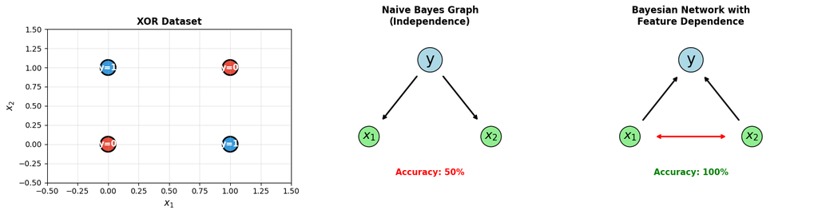

```
======================================================================
CONCLUSION: Allowing feature dependence enables perfect XOR classification!
The naive independence assumption is what causes Naive Bayes to fail.
======================================================================
```

```python
import numpy as np
import matplotlib.pyplot as plt

print("="*70)
print("Exercise 3: Bayesian Networks - XOR with Joint Distribution")
print("="*70)

# XOR Dataset
X = np.array([[0, 0], [0, 1], [1, 0], [1, 1]])
y = np.array([0, 1, 1, 0])

# Model 1: Naive Bayes (assumes independence)
print("\n--- Model 1: Naive Bayes (Independence Assumption) ---")

# Compute P(x1|y) and P(x2|y) separately
P_x1_given_y = {0: 0.5, 1: 0.5}  # Same for both classes
P_x2_given_y = {0: 0.5, 1: 0.5}  # Same for both classes

print("P(x1=1|y=0) = 0.5, P(x1=1|y=1) = 0.5")
print("P(x2=1|y=0) = 0.5, P(x2=1|y=1) = 0.5")
print("→ Features provide no information about class!")

# Model 2: Full Joint Distribution (no independence assumption)
print("\n--- Model 2: Full Joint Distribution (No Independence) ---")

# P(x1, x2 | y) - full joint distribution
P_joint_given_y0 = {
    (0, 0): 0.5,  # [0,0] → y=0
    (0, 1): 0.0,
    (1, 0): 0.0,
    (1, 1): 0.5   # [1,1] → y=0
}

P_joint_given_y1 = {
    (0, 0): 0.0,
    (0, 1): 0.5,  # [0,1] → y=1
    (1, 0): 0.5,  # [1,0] → y=1
    (1, 1): 0.0
}

print("P(x1,x2|y=0): [0,0]=0.5, [1,1]=0.5, others=0")
print("P(x1,x2|y=1): [0,1]=0.5, [1,0]=0.5, others=0")

# Classification using full joint
print("\n--- Classification Results ---")
P_y = {0: 0.5, 1: 0.5}

results_naive = []
results_joint = []

for i, x in enumerate(X):
    key = (x[0], x[1])
    true_label = y[i]

    # Naive Bayes: P(y|x) ∝ P(y) * P(x1|y) * P(x2|y)
    naive_post_0 = P_y[0] * 0.5 * 0.5  # = 0.125
    naive_post_1 = P_y[1] * 0.5 * 0.5  # = 0.125
    naive_pred = 0 if naive_post_0 >= naive_post_1 else 1

    # Full joint: P(y|x) ∝ P(y) * P(x1,x2|y)
    joint_post_0 = P_y[0] * P_joint_given_y0[key]
    joint_post_1 = P_y[1] * P_joint_given_y1[key]
    joint_pred = 0 if joint_post_0 > joint_post_1 else 1

    results_naive.append(naive_pred == true_label)
    results_joint.append(joint_pred == true_label)

    print(f"x={x}: True={true_label}")
    print(f"  Naive: P(0|x)∝{naive_post_0:.3f}, P(1|x)∝{naive_post_1:.3f} → Pred={naive_pred} {'✓' if naive_pred==true_label else '✗'}")
    print(f"  Joint: P(0|x)∝{joint_post_0:.3f}, P(1|x)∝{joint_post_1:.3f} → Pred={joint_pred} {'✓' if joint_pred==true_label else '✗'}")

print("\n--- Accuracy Comparison ---")
print(f"Naive Bayes: {sum(results_naive)}/4 = {100*sum(results_naive)/4:.0f}%")
print(f"Full Joint:  {sum(results_joint)}/4 = {100*sum(results_joint)/4:.0f}%")

# Visualization
fig, axes = plt.subplots(1, 3, figsize=(15, 4))

# XOR data
colors = ['#E74C3C' if label == 0 else '#3498DB' for label in y]
axes[0].scatter(X[:, 0], X[:, 1], c=colors, s=400, edgecolors='black', linewidth=2)
for i, (xi, label) in enumerate(zip(X, y)):
    axes[0].annotate(f'y={label}', (xi[0], xi[1]), fontsize=11, ha='center', va='center', color='white', fontweight='bold')
axes[0].set_xlabel('$x_1$', fontsize=12)
axes[0].set_ylabel('$x_2$', fontsize=12)
axes[0].set_title('XOR Dataset', fontsize=12, fontweight='bold')
axes[0].set_xlim([-0.5, 1.5])
axes[0].set_ylim([-0.5, 1.5])
axes[0].grid(True, alpha=0.3)

# Naive Bayes graph
axes[1].text(0.5, 0.8, 'y', fontsize=20, ha='center', va='center',
            bbox=dict(boxstyle='circle', facecolor='lightblue', edgecolor='black'))
axes[1].text(0.25, 0.3, '$x_1$', fontsize=16, ha='center', va='center',
            bbox=dict(boxstyle='circle', facecolor='lightgreen', edgecolor='black'))
axes[1].text(0.75, 0.3, '$x_2$', fontsize=16, ha='center', va='center',
            bbox=dict(boxstyle='circle', facecolor='lightgreen', edgecolor='black'))
axes[1].annotate('', xy=(0.3, 0.4), xytext=(0.45, 0.7), arrowprops=dict(arrowstyle='->', lw=2))
axes[1].annotate('', xy=(0.7, 0.4), xytext=(0.55, 0.7), arrowprops=dict(arrowstyle='->', lw=2))
axes[1].set_xlim([0, 1])
axes[1].set_ylim([0, 1])
axes[1].set_title('Naive Bayes Graph\n(Independence)', fontsize=12, fontweight='bold')
axes[1].axis('off')
axes[1].text(0.5, 0.05, 'Accuracy: 50%', ha='center', fontsize=11, color='red', fontweight='bold')

# Full joint graph
axes[2].text(0.5, 0.8, 'y', fontsize=20, ha='center', va='center',
            bbox=dict(boxstyle='circle', facecolor='lightblue', edgecolor='black'))
axes[2].text(0.25, 0.3, '$x_1$', fontsize=16, ha='center', va='center',
            bbox=dict(boxstyle='circle', facecolor='lightgreen', edgecolor='black'))
axes[2].text(0.75, 0.3, '$x_2$', fontsize=16, ha='center', va='center',
            bbox=dict(boxstyle='circle', facecolor='lightgreen', edgecolor='black'))
axes[2].annotate('', xy=(0.45, 0.7), xytext=(0.3, 0.4), arrowprops=dict(arrowstyle='->', lw=2))
axes[2].annotate('', xy=(0.55, 0.7), xytext=(0.7, 0.4), arrowprops=dict(arrowstyle='->', lw=2))
axes[2].annotate('', xy=(0.65, 0.3), xytext=(0.35, 0.3), arrowprops=dict(arrowstyle='<->', lw=2, color='red'))
axes[2].set_xlim([0, 1])
axes[2].set_ylim([0, 1])
axes[2].set_title('Bayesian Network with\nFeature Dependence', fontsize=12, fontweight='bold')
axes[2].axis('off')
axes[2].text(0.5, 0.05, 'Accuracy: 100%', ha='center', fontsize=11, color='green', fontweight='bold')

plt.tight_layout()
plt.show()

print(f"\n{'='*70}")
print("CONCLUSION: Allowing feature dependence enables perfect XOR classification!")
print("The naive independence assumption is what causes Naive Bayes to fail.")
print(f"{'='*70}")
```

**Python code demonstrates that modeling feature dependence enables perfect XOR classification.**

### Key Takeaways from Exercise 3:

1. **Naive Bayes is a special case** of Bayesian networks with a specific independence structure
2. **The graph structure encodes assumptions** about conditional dependencies
3. **XOR requires feature interaction** - the label depends on $(x_1, x_2)$ jointly, not separately
4. **More expressive models** (like neural networks or Bayesian networks with dependence) can capture such interactions
5. **Trade-off:** More expressiveness requires more parameters and data to estimate

### Connection to Deep Learning:

This is one reason why **neural networks** are more powerful than Naive Bayes for complex tasks:

- Neural networks can learn **arbitrary feature interactions** through hidden layers
- The XOR problem was historically important in showing the limitations of single-layer perceptrons
- Multi-layer networks solve XOR by learning a representation that makes the problem linearly separable

## Exercise Solutions Summary

| Exercise | Topic | Key Finding |
| --- | --- | --- |
| 1 | XOR Problem | Naive Bayes fails (50% accuracy) due to violated independence assumption |
| 2 | Laplace Smoothing | Essential to prevent zero probabilities from causing classification failures |
| 3 | Bayesian Networks | Allowing feature dependence enables perfect XOR classification |

## 5. Extended Practice Problems

This section provides additional practice problems beyond the D2L textbook exercises. These examples demonstrate Naive Bayes classification in various real-world scenarios.

### Extended Exercise 1: Binary Classification

**Problem:** Suppose we have a dataset with two binary features $x_1, x_2$, and a binary class $y \in \{0, 1\}$. The probabilities are given as follows:

| $y$ | $P(y)$ | $P(x_1 = 1 \mid y)$ | $P(x_2 = 1 \mid y)$ |
| --- | --- | --- | --- |
| 0 | 0.4 | 0.8 | 0.7 |
| 1 | 0.6 | 0.3 | 0.4 |

Given a new sample with features: $x_1 = 1, x_2 = 0$, classify this sample using Naive Bayes.

### Solution:

**Step 1: Compute probability for class $y = 0$:**

$$ P(y = 0|\mathbf{x}) \propto P(y = 0) \cdot P(x_1 = 1|y = 0) \cdot P(x_2 = 0|y = 0) = 0.4 \times 0.8 \times 0.3 = 0.096 $$

**Step 2: Compute probability for class $y = 1$:**

$$ P(y = 1|\mathbf{x}) \propto P(y = 1) \cdot P(x_1 = 1|y = 1) \cdot P(x_2 = 0|y = 1) = 0.6 \times 0.3 \times 0.6 = 0.108 $$

**Step 3: Classification:**

$$ 0.108 > 0.096 \quad \Rightarrow \quad \hat{y} = 1 $$

```python
import numpy as np

P_y = {0: 0.4, 1: 0.6}
P_xy = {
    0: [0.8, 0.7],
    1: [0.3, 0.4]
}
t = [1, 0]  # x1=1, x2=0

posteriors = {}
for cls in P_y:
    prob = P_y[cls]
    for i, feature in enumerate(t):
        prob *= P_xy[cls][i] if feature == 1 else (1 - P_xy[cls][i])
    posteriors[cls] = prob

prediction = max(posteriors, key=posteriors.get)

print("Extended Exercise 1: Binary Classification")
print("="*50)
print(f"Posterior Probabilities: {posteriors}")
print(f"Predicted class: {prediction}")
```

```
Extended Exercise 1: Binary Classification
==================================================
Posterior Probabilities: {0: 0.09600000000000003, 1: 0.108}
Predicted class: 1
```

### Extended Exercise 2: Product Purchase Prediction

**Problem:** Determine whether a person will buy a product ($y = 1$) or not ($y = 0$) based on:

- $x_1$: Saw an advertisement (1: yes, 0: no)
- $x_2$: Friend recommended (1: yes, 0: no)

| Class $y$ | Prior $P(y)$ | $P(x_1 = 1 \mid y)$ | $P(x_2 = 1 \mid y)$ |
| --- | --- | --- | --- |
| 0 (No) | 0.7 | 0.2 | 0.1 |
| 1 (Yes) | 0.3 | 0.6 | 0.8 |

Classify a customer who saw the advertisement but didn't have a friend recommendation ($x_1 = 1, x_2 = 0$).

### Solution:

**For $y = 0$:** $P(y=0|\mathbf{x}) \propto 0.7 \times 0.2 \times 0.9 = 0.126$

**For $y = 1$:** $P(y=1|\mathbf{x}) \propto 0.3 \times 0.6 \times 0.2 = 0.036$

**Normalized:** $P(y=0|\mathbf{x}) = 0.778$, $P(y=1|\mathbf{x}) = 0.222$

**Result:** $\hat{y} = 0$ (Not buy)

```python
P_y = {0: 0.7, 1: 0.3}
P_xy = {
    0: [0.2, 0.1],
    1: [0.6, 0.8]
}
t = [1, 0]  # Saw ad, no friend recommendation

posteriors = {}
for cls in P_y:
    prob = P_y[cls]
    for i, feature in enumerate(t):
        prob *= P_xy[cls][i] if feature == 1 else (1 - P_xy[cls][i])
    posteriors[cls] = prob

total = sum(posteriors.values())
normalized = {k: v/total for k, v in posteriors.items()}

print("Extended Exercise 2: Product Purchase Prediction")
print("="*50)
print(f"Unnormalized: {posteriors}")
print(f"Normalized: P(No Buy)={normalized[0]:.4f}, P(Buy)={normalized[1]:.4f}")
print(f"Prediction: {'Buy' if max(posteriors, key=posteriors.get)==1 else 'Not Buy'}")
```

```
Extended Exercise 2: Product Purchase Prediction
==================================================
Unnormalized: {0: 0.126, 1: 0.03599999999999999}
Normalized: P(No Buy)=0.7778, P(Buy)=0.2222
Prediction: Not Buy
```

### Extended Exercise 3: Medical Diagnosis (Flu Detection)

**Problem:** Classify patients as having "Flu" ($y = 1$) or "Healthy" ($y = 0$) based on:

- $x_1$: Fever (1 = yes, 0 = no)
- $x_2$: Cough (1 = yes, 0 = no)

| Class $y$ | Prior $P(y)$ | $P(x_1 = 1 \mid y)$ (Fever) | $P(x_2 = 1 \mid y)$ (Cough) |
| --- | --- | --- | --- |
| 0 (Healthy) | 0.9 | 0.1 | 0.2 |
| 1 (Flu) | 0.1 | 0.8 | 0.7 |

Classify a patient with both fever and cough ($x_1 = 1, x_2 = 1$).

### Solution:

**For Healthy:** $P(y=0|\mathbf{x}) \propto 0.9 \times 0.1 \times 0.2 = 0.018$

**For Flu:** $P(y=1|\mathbf{x}) \propto 0.1 \times 0.8 \times 0.7 = 0.056$

**Normalized:** $P(Healthy) = 24.32\%$, $P(Flu) = 75.68\%$

**Result:** $\hat{y} = 1$ (Flu)

**Insight:** Despite low prior (10%), both symptoms strongly indicate Flu!

```
Extended Exercise 3: Medical Diagnosis
==================================================
Patient symptoms: Fever=Yes, Cough=Yes
Prior: P(Healthy)=90%, P(Flu)=10%
Posterior: P(Healthy)=24.32%, P(Flu)=75.68%
Diagnosis: Flu

Bayesian updating: Prior 10% Flu → Posterior 75.7% Flu!
```

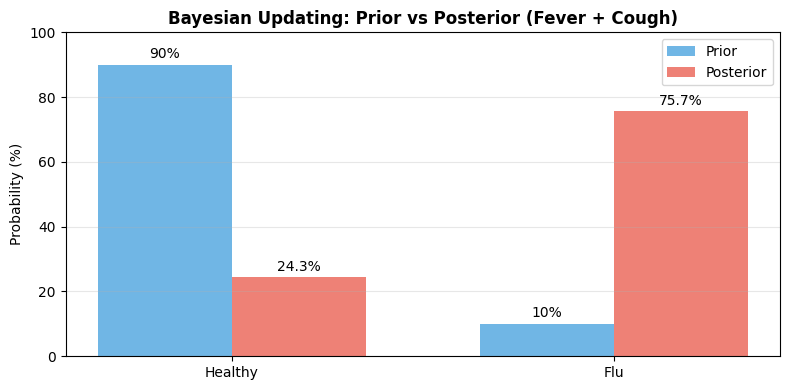

```python
import matplotlib.pyplot as plt
import numpy as np

P_y = {0: 0.9, 1: 0.1}
P_xy = {
    0: [0.1, 0.2],
    1: [0.8, 0.7]
}
t = [1, 1]  # Fever and Cough

posteriors = {}
for cls in P_y:
    prob = P_y[cls]
    for i, feature in enumerate(t):
        prob *= P_xy[cls][i] if feature == 1 else (1 - P_xy[cls][i])
    posteriors[cls] = prob

total = sum(posteriors.values())
normalized = {k: v/total for k, v in posteriors.items()}

print("Extended Exercise 3: Medical Diagnosis")
print("="*50)
print(f"Patient symptoms: Fever=Yes, Cough=Yes")
print(f"Prior: P(Healthy)=90%, P(Flu)=10%")
print(f"Posterior: P(Healthy)={normalized[0]:.2%}, P(Flu)={normalized[1]:.2%}")
print(f"Diagnosis: {'Flu' if max(posteriors, key=posteriors.get)==1 else 'Healthy'}")
print("\nBayesian updating: Prior 10% Flu → Posterior 75.7% Flu!")

# Visualization
fig, ax = plt.subplots(figsize=(8, 4))
categories = ['Healthy', 'Flu']
priors = [P_y[0]*100, P_y[1]*100]
posteriors_pct = [normalized[0]*100, normalized[1]*100]

x = np.arange(len(categories))
width = 0.35

bars1 = ax.bar(x - width/2, priors, width, label='Prior', color='#3498DB', alpha=0.7)
bars2 = ax.bar(x + width/2, posteriors_pct, width, label='Posterior', color='#E74C3C', alpha=0.7)

ax.set_ylabel('Probability (%)')
ax.set_title('Bayesian Updating: Prior vs Posterior (Fever + Cough)', fontweight='bold')
ax.set_xticks(x)
ax.set_xticklabels(categories)
ax.legend()
ax.set_ylim([0, 100])
ax.grid(True, alpha=0.3, axis='y')

for bar, val in zip(bars1, priors):
    ax.text(bar.get_x() + bar.get_width()/2, val + 2, f'{val:.0f}%', ha='center', fontsize=10)
for bar, val in zip(bars2, posteriors_pct):
    ax.text(bar.get_x() + bar.get_width()/2, val + 2, f'{val:.1f}%', ha='center', fontsize=10)

plt.tight_layout()
plt.show()
```

## References

[1] Zhang, A., Lipton, Z. C., Li, M., & Smola, A. J. (2023). *Dive into Deep Learning*. Cambridge University Press. Retrieved from https://d2l.ai

- Chapter 22.9: Naive Bayes
- Section 4.1: Softmax Regression

[2] Bishop, C. M. (2006). *Pattern Recognition and Machine Learning*. Springer.

- Chapter 2: Probability Distributions (pp. 67-88)
- Chapter 4: Linear Models for Classification (pp. 179-224)

[3] Murphy, K. P. (2012). *Machine Learning: A Probabilistic Perspective*. MIT Press.

- Chapter 3: Generative Models for Discrete Data (pp. 82-95)
- Chapter 8: Graphical Models (pp. 239-258)